# 20203986남덕우_Wine Quality_회귀분석

### Business Analytics (6/11)

```python
import pandas as pd
import matplotlib.pyplot as plt
import seaborn as sns
import numpy as np
import scipy
from sklearn.preprocessing import StandardScaler
from tqdm import tqdm_notebook
import statsmodels.api as sm
from scipy import stats
import matplotlib
from IPython.display import set_matplotlib_formats
from sklearn.metrics import r2_score, mean_squared_error, mean_absolute_error
import warnings
from sklearn.metrics import r2_score, mean_squared_error


warnings.filterwarnings("ignore")  #경고 메시지 무시
matplotlib.rc("font", family="AppleGothic")  #폰트설정
set_matplotlib_formats("retina")  # 그래프 해상도
pd.set_option('display.max_rows', 500)  # 보여주는 row, columns수 확장
pd.set_option('display.max_columns', 500)
```

#### 엑셀파일 불러오기

```python
red = pd.read_excel("desktop/WineQuality_Red_White.xlsx", sheet_name=0)
white = pd.read_excel("desktop/WineQuality_Red_White.xlsx", sheet_name=1)
```

```python
white.shape, red.shape
```

```
((4898, 12), (1599, 12))
```

```python
display(red.head(3), white.head(3))
```

|  | fixed acidity | volatile acidity | citric acid | residual sugar | chlorides | free sulfur dioxide | total sulfur dioxide | density | pH | sulphates | alcohol | quality |
| --- | --- | --- | --- | --- | --- | --- | --- | --- | --- | --- | --- | --- |
| 0 | 7.4 | 0.70 | 0.00 | 1.9 | 0.076 | 11.0 | 34.0 | 0.9978 | 3.51 | 0.56 | 9.4 | 5 |
| 1 | 7.8 | 0.88 | 0.00 | 2.6 | 0.098 | 25.0 | 67.0 | 0.9968 | 3.20 | 0.68 | 9.8 | 5 |
| 2 | 7.8 | 0.76 | 0.04 | 2.3 | 0.092 | 15.0 | 54.0 | 0.9970 | 3.26 | 0.65 | 9.8 | 5 |

|  | fixed acidity | volatile acidity | citric acid | residual sugar | chlorides | free sulfur dioxide | total sulfur dioxide | density | pH | sulphates | alcohol | quality |
| --- | --- | --- | --- | --- | --- | --- | --- | --- | --- | --- | --- | --- |
| 0 | 7.0 | 0.27 | 0.36 | 20.7 | 0.045 | 45.0 | 170.0 | 1.0010 | 3.00 | 0.45 | 8.8 | 6 |
| 1 | 6.3 | 0.30 | 0.34 | 1.6 | 0.049 | 14.0 | 132.0 | 0.9940 | 3.30 | 0.49 | 9.5 | 6 |
| 2 | 8.1 | 0.28 | 0.40 | 6.9 | 0.050 | 30.0 | 97.0 | 0.9951 | 3.26 | 0.44 | 10.1 | 6 |

#### 결측치확인

```python
# 두 데이터셋모두 결측치가 존재하지 않는다
display(red.isna().mean(), white.isna().mean())
```

```
fixed acidity           0.0
volatile acidity        0.0
citric acid             0.0
residual sugar          0.0
chlorides               0.0
free sulfur dioxide     0.0
total sulfur dioxide    0.0
density                 0.0
pH                      0.0
sulphates               0.0
alcohol                 0.0
quality                 0.0
dtype: float64
```

```
fixed acidity           0.0
volatile acidity        0.0
citric acid             0.0
residual sugar          0.0
chlorides               0.0
free sulfur dioxide     0.0
total sulfur dioxide    0.0
density                 0.0
pH                      0.0
sulphates               0.0
alcohol                 0.0
quality                 0.0
dtype: float64
```

```python
#### 기본통계
red.describe()
```

|  | fixed acidity | volatile acidity | citric acid | residual sugar | chlorides | free sulfur dioxide | total sulfur dioxide | density | pH | sulphates | alcohol | quality |
| --- | --- | --- | --- | --- | --- | --- | --- | --- | --- | --- | --- | --- |
| count | 1599.000000 | 1599.000000 | 1599.000000 | 1599.000000 | 1599.000000 | 1599.000000 | 1599.000000 | 1599.000000 | 1599.000000 | 1599.000000 | 1599.000000 | 1599.000000 |
| mean | 8.319637 | 0.527821 | 0.270976 | 2.538806 | 0.087467 | 15.874922 | 46.467792 | 0.996747 | 3.311113 | 0.658149 | 10.422983 | 5.636023 |
| std | 1.741096 | 0.179060 | 0.194801 | 1.409928 | 0.047065 | 10.460157 | 32.895324 | 0.001887 | 0.154386 | 0.169507 | 1.065668 | 0.807569 |
| min | 4.600000 | 0.120000 | 0.000000 | 0.900000 | 0.012000 | 1.000000 | 6.000000 | 0.990070 | 2.740000 | 0.330000 | 8.400000 | 3.000000 |
| 25% | 7.100000 | 0.390000 | 0.090000 | 1.900000 | 0.070000 | 7.000000 | 22.000000 | 0.995600 | 3.210000 | 0.550000 | 9.500000 | 5.000000 |
| 50% | 7.900000 | 0.520000 | 0.260000 | 2.200000 | 0.079000 | 14.000000 | 38.000000 | 0.996750 | 3.310000 | 0.620000 | 10.200000 | 6.000000 |
| 75% | 9.200000 | 0.640000 | 0.420000 | 2.600000 | 0.090000 | 21.000000 | 62.000000 | 0.997835 | 3.400000 | 0.730000 | 11.100000 | 6.000000 |
| max | 15.900000 | 1.580000 | 1.000000 | 15.500000 | 0.611000 | 72.000000 | 289.000000 | 1.003690 | 4.010000 | 2.000000 | 14.900000 | 8.000000 |

```python
white.describe()
```

|  | fixed acidity | volatile acidity | citric acid | residual sugar | chlorides | free sulfur dioxide | total sulfur dioxide | density | pH | sulphates | alcohol | quality |
| --- | --- | --- | --- | --- | --- | --- | --- | --- | --- | --- | --- | --- |
| count | 4898.000000 | 4898.000000 | 4898.000000 | 4898.000000 | 4898.000000 | 4898.000000 | 4898.000000 | 4898.000000 | 4898.000000 | 4898.000000 | 4898.000000 | 4898.000000 |
| mean | 6.854788 | 0.278241 | 0.334192 | 6.391415 | 0.045772 | 35.308085 | 138.360657 | 0.994027 | 3.188267 | 0.489847 | 10.514267 | 5.877909 |
| std | 0.843868 | 0.100795 | 0.121020 | 5.072058 | 0.021848 | 17.007137 | 42.498065 | 0.002991 | 0.151001 | 0.114126 | 1.230621 | 0.885639 |
| min | 3.800000 | 0.080000 | 0.000000 | 0.600000 | 0.009000 | 2.000000 | 9.000000 | 0.987110 | 2.720000 | 0.220000 | 8.000000 | 3.000000 |
| 25% | 6.300000 | 0.210000 | 0.270000 | 1.700000 | 0.036000 | 23.000000 | 108.000000 | 0.991723 | 3.090000 | 0.410000 | 9.500000 | 5.000000 |
| 50% | 6.800000 | 0.260000 | 0.320000 | 5.200000 | 0.043000 | 34.000000 | 134.000000 | 0.993740 | 3.180000 | 0.470000 | 10.400000 | 6.000000 |
| 75% | 7.300000 | 0.320000 | 0.390000 | 9.900000 | 0.050000 | 46.000000 | 167.000000 | 0.996100 | 3.280000 | 0.550000 | 11.400000 | 6.000000 |
| max | 14.200000 | 1.100000 | 1.660000 | 65.800000 | 0.346000 | 289.000000 | 440.000000 | 1.038980 | 3.820000 | 1.080000 | 14.200000 | 9.000000 |

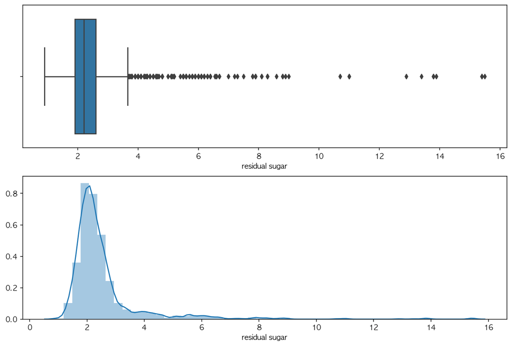

```python
a, b = plt.subplots(2, 1, figsize=(12, 8))

sns.boxplot(red["residual sugar"], ax=b[0])
sns.distplot(red["residual sugar"], ax=b[1])

plt.show()
```

#### 전체 BOXPLOT 확인

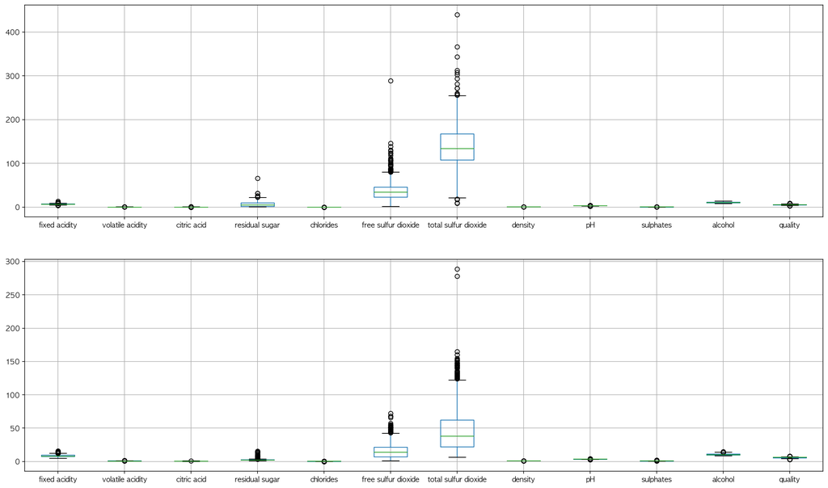

```python
plt.subplots(figsize = (20, 12))

plt.subplot(211)
white.boxplot()

plt.subplot(212)
red.boxplot()
plt.show()
```

```python
#### Scaling을 진행할 떄 outlier영향을 최소화하기 위해 RobustScaler를 사용하도록 한다
```

#### Outlier Trimming

```python
a = ["free sulfur dioxide", "total sulfur dioxide"]

if type(a) == list:
    print(a)
```

```
['free sulfur dioxide', 'total sulfur dioxide']
```

```python
def find_normal(df, variable):

    if type(variable) == list:
        for i in variable:

            upper_boundary = df[i].mean() + 3 * df[i].std()
            lower_boundary = df[i].mean() - 3 * df[i].std()

            df = df[(df[i] < upper_boundary) & (df[i] > lower_boundary)]

    else:
        upper_boundary = df[variable].mean() + 3 * df[variable].std()
        lower_boundary = df[variable].mean() - 3 * df[variable].std()

        df = df[(df[variable] < upper_boundary) \
                & (df[variable] > lower_boundary)]

    return df
```

```python
# feature = list(white.columns[white.columns != "quality"])
```

```python
white = find_normal(white, ["free sulfur dioxide", "total sulfur dioxide", "residual sugar"])
red = find_normal(red, ["free sulfur dioxide", "total sulfur dioxide", "residual sugar"])
```

```python
white.shape, red.shape
```

```
((4849, 12), (1521, 12))
```

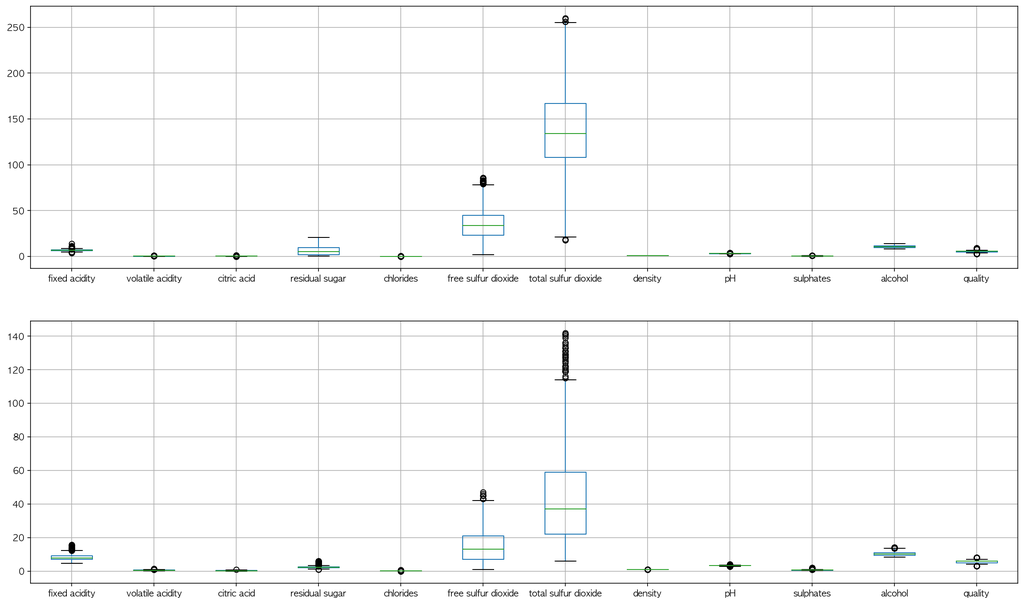

```python
plt.subplots(figsize = (20, 12))

plt.subplot(211)
white.boxplot()

plt.subplot(212)
red.boxplot()
plt.show()
```

#### Diagnostic_plots

```python
def diagnostic_plots(df, variable):

    # define figure size
    plt.figure(figsize = (16, 4))

    #histogram
    plt.subplot(1, 3, 1)
    sns.distplot(df[variable], bins = 30)
    plt.title("Histogram")

    #Q-Q plot
    plt.subplot(1, 3, 2)
    stats.probplot(df[variable], dist = "norm", plot = plt)
    plt.ylabel("RM quantiles")

    #boxplot
    plt.subplot(1, 3, 3)
    sns.boxplot(y = df[variable])
    plt.title("Boxplot")

    plt.show()
```

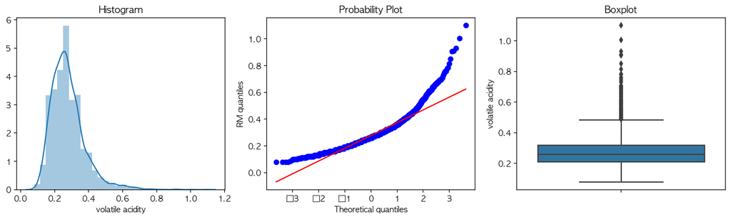

```python
diagnostic_plots(white, "volatile acidity")
```

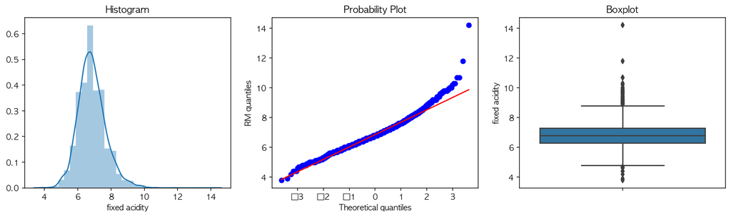

```python
diagnostic_plots(white, "fixed acidity")
```

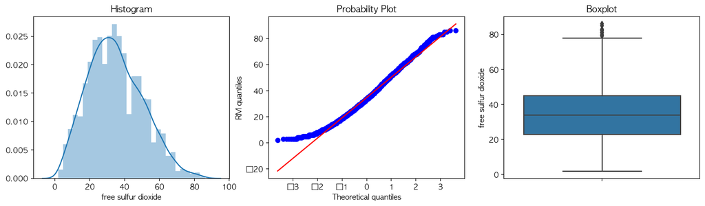

```python
diagnostic_plots(white, "free sulfur dioxide")
```

#### Shapiro Test

```python
from scipy.stats import shapiro , normaltest , anderson , kstest

normal = []
notnormal = []
for var in red.columns:
    stat, p  = shapiro(red[var].dropna().values)
    stat, p  = normaltest(red[var].dropna().values)
    alpha = 0.05
    if p > alpha :
        normal.append(var)
    else :
        notnormal.append(var)
```

```python
notnormal
```

```
['fixed acidity',
 'volatile acidity',
 'citric acid',
 'residual sugar',
 'chlorides',
 'free sulfur dioxide',
 'total sulfur dioxide',
 'density',
 'pH',
 'sulphates',
 'alcohol',
 'quality']
```

```python
### Shapiro Test

from scipy.stats import shapiro , normaltest , anderson , kstest

normal = []
notnormal = []
for var in white.columns:
    stat, p  = shapiro(white[var].dropna().values)
    stat, p  = normaltest(white[var].dropna().values)
    alpha = 0.05
    if p > alpha :
        normal.append(var)
    else :
        notnormal.append(var)
```

```python
notnormal
```

```
['fixed acidity',
 'volatile acidity',
 'citric acid',
 'residual sugar',
 'chlorides',
 'free sulfur dioxide',
 'total sulfur dioxide',
 'density',
 'pH',
 'sulphates',
 'alcohol',
 'quality']
```

#### white wine

```python
cor = white.corr("spearman") **2
cor.style.background_gradient(cmap="Blues")
```

|  | fixed acidity | volatile acidity | citric acid | residual sugar | chlorides | free sulfur dioxide | total sulfur dioxide | density | pH | sulphates | alcohol | quality |
| --- | --- | --- | --- | --- | --- | --- | --- | --- | --- | --- | --- | --- |
| fixed acidity | 1 | 0.00222852 | 0.0872958 | 0.0105736 | 0.00859555 | 0.000541612 | 0.0122994 | 0.0718686 | 0.175298 | 0.000216709 | 0.0111392 | 0.00696836 |
| volatile acidity | 0.00222852 | 1 | 0.0229043 | 0.0116844 | 2.93128e-05 | 0.00599551 | 0.0144324 | 4.61509e-05 | 0.00200487 | 0.000220489 | 0.0011706 | 0.0376737 |
| citric acid | 0.0872958 | 0.0229043 | 1 | 0.000395704 | 0.000922957 | 0.00893833 | 0.00931651 | 0.00811637 | 0.0208412 | 0.00579416 | 0.000938674 | 0.000226238 |
| residual sugar | 0.0105736 | 0.0116844 | 0.000395704 | 1 | 0.0504217 | 0.123085 | 0.188202 | 0.607053 | 0.030703 | 1.7312e-06 | 0.198216 | 0.00678353 |
| chlorides | 0.00859555 | 2.93128e-05 | 0.000922957 | 0.0504217 | 1 | 0.0273222 | 0.140536 | 0.258081 | 0.00280724 | 0.00874163 | 0.327865 | 0.0999372 |
| free sulfur dioxide | 0.000541612 | 0.00599551 | 0.00893833 | 0.123085 | 0.0273222 | 1 | 0.376131 | 0.109703 | 1.59565e-05 | 0.00268285 | 0.0738318 | 0.00085091 |
| total sulfur dioxide | 0.0122994 | 0.0144324 | 0.00931651 | 0.188202 | 0.140536 | 0.376131 | 1 | 0.3214 | 9.53485e-05 | 0.024845 | 0.227864 | 0.0374572 |
| density | 0.0718686 | 4.61509e-05 | 0.00811637 | 0.607053 | 0.258081 | 0.109703 | 0.3214 | 1 | 0.011345 | 0.00966067 | 0.67856 | 0.12129 |
| pH | 0.175298 | 0.00200487 | 0.0208412 | 0.030703 | 0.00280724 | 1.59565e-05 | 9.53485e-05 | 0.011345 | 1 | 0.0192526 | 0.0218383 | 0.0122782 |
| sulphates | 0.000216709 | 0.000220489 | 0.00579416 | 1.7312e-06 | 0.00874163 | 0.00268285 | 0.024845 | 0.00966067 | 0.0192526 | 1 | 0.00227605 | 0.000917613 |
| alcohol | 0.0111392 | 0.0011706 | 0.000938674 | 0.198216 | 0.327865 | 0.0738318 | 0.227864 | 0.67856 | 0.0218383 | 0.00227605 | 1 | 0.195287 |
| quality | 0.00696836 | 0.0376737 | 0.000226238 | 0.00678353 | 0.0999372 | 0.00085091 | 0.0374572 | 0.12129 | 0.0122782 | 0.000917613 | 0.195287 | 1 |

#### red wine

```python
cor = red.corr("spearman") **2
cor.style.background_gradient(cmap="Blues")
```

|  | fixed acidity | volatile acidity | citric acid | residual sugar | chlorides | free sulfur dioxide | total sulfur dioxide | density | pH | sulphates | alcohol | quality |
| --- | --- | --- | --- | --- | --- | --- | --- | --- | --- | --- | --- | --- |
| fixed acidity | 1 | 0.0852207 | 0.447272 | 0.0532244 | 0.0654118 | 0.0322624 | 0.00699372 | 0.395318 | 0.515557 | 0.0385467 | 0.00420424 | 0.0125137 |
| volatile acidity | 0.0852207 | 1 | 0.379746 | 0.00094619 | 0.0187083 | 1.7697e-05 | 0.0066035 | 7.61451e-05 | 0.0578009 | 0.114142 | 0.0434086 | 0.138531 |
| citric acid | 0.447272 | 0.379746 | 1 | 0.0287374 | 0.0156525 | 0.0066549 | 4.92366e-05 | 0.127099 | 0.301336 | 0.111652 | 0.0077627 | 0.0444463 |
| residual sugar | 0.0532244 | 0.00094619 | 0.0287374 | 1 | 0.0469733 | 0.00168547 | 0.0139135 | 0.161788 | 0.00588225 | 0.0012386 | 0.0190475 | 0.0017959 |
| chlorides | 0.0654118 | 0.0187083 | 0.0156525 | 0.0469733 | 1 | 0.00049476 | 0.0149176 | 0.166021 | 0.0567265 | 3.467e-05 | 0.0739037 | 0.0326061 |
| free sulfur dioxide | 0.0322624 | 1.7697e-05 | 0.0066549 | 0.00168547 | 0.00049476 | 1 | 0.60689 | 0.00450579 | 0.018012 | 0.00261802 | 0.00309798 | 0.00257723 |
| total sulfur dioxide | 0.00699372 | 0.0066035 | 4.92366e-05 | 0.0139135 | 0.0149176 | 0.60689 | 1 | 0.0140626 | 5.90786e-05 | 5.38109e-05 | 0.059256 | 0.0351001 |
| density | 0.395318 | 7.61451e-05 | 0.127099 | 0.161788 | 0.166021 | 0.00450579 | 0.0140626 | 1 | 0.0994191 | 0.0224022 | 0.214298 | 0.0312228 |
| pH | 0.515557 | 0.0578009 | 0.301336 | 0.00588225 | 0.0567265 | 0.018012 | 5.90786e-05 | 0.0994191 | 1 | 0.0064075 | 0.0318537 | 0.0023133 |
| sulphates | 0.0385467 | 0.114142 | 0.111652 | 0.0012386 | 3.467e-05 | 0.00261802 | 5.38109e-05 | 0.0224022 | 0.0064075 | 1 | 0.0472612 | 0.148019 |
| alcohol | 0.00420424 | 0.0434086 | 0.0077627 | 0.0190475 | 0.0739037 | 0.00309798 | 0.059256 | 0.214298 | 0.0318537 | 0.0472612 | 1 | 0.225943 |
| quality | 0.0125137 | 0.138531 | 0.0444463 | 0.0017959 | 0.0326061 | 0.00257723 | 0.0351001 | 0.0312228 | 0.0023133 | 0.148019 | 0.225943 | 1 |

```python
features = white.columns[white.columns != "quality"]

y_white = white["quality"]
y_red = red["quality"]

X_white = white[features]
X_red = red[features]
```

#### Normalizing : Robust

```python
from sklearn.linear_model import LinearRegression
from sklearn.preprocessing import MinMaxScaler, StandardScaler, RobustScaler

rb = RobustScaler()
for i in [X_white, X_red]:
    i[i.columns] = rb.fit_transform(i)
```

```python
display(X_white.head(3), X_red.head(3))
```

|  | fixed acidity | volatile acidity | citric acid | residual sugar | chlorides | free sulfur dioxide | total sulfur dioxide | density | pH | sulphates | alcohol |
| --- | --- | --- | --- | --- | --- | --- | --- | --- | --- | --- | --- |
| 0 | 0.2 | 0.090909 | 0.333333 | 1.901840 | 0.142857 | 0.500000 | 0.610169 | 1.652273 | -0.947368 | -0.142857 | -0.842105 |
| 1 | -0.5 | 0.363636 | 0.166667 | -0.441718 | 0.428571 | -0.909091 | -0.033898 | 0.061364 | 0.631579 | 0.142857 | -0.473684 |
| 2 | 1.3 | 0.181818 | 0.666667 | 0.208589 | 0.500000 | -0.181818 | -0.627119 | 0.311364 | 0.421053 | -0.214286 | -0.157895 |

|  | fixed acidity | volatile acidity | citric acid | residual sugar | chlorides | free sulfur dioxide | total sulfur dioxide | density | pH | sulphates | alcohol |
| --- | --- | --- | --- | --- | --- | --- | --- | --- | --- | --- | --- |
| 0 | -0.238095 | 0.72 | -0.757576 | -0.500000 | -0.15 | -0.142857 | -0.081081 | 0.500000 | 1.052632 | -0.333333 | -0.50 |
| 1 | -0.047619 | 1.44 | -0.757576 | 0.666667 | 0.95 | 0.857143 | 0.810811 | 0.045455 | -0.578947 | 0.333333 | -0.25 |
| 2 | -0.047619 | 0.96 | -0.636364 | 0.166667 | 0.65 | 0.142857 | 0.459459 | 0.136364 | -0.263158 | 0.166667 | -0.25 |

### Q1.1

Red wine와 White wine 데이터를 따로 나누어서 LR을 돌려보고 결과를 비교하시오.

(1)R-Square, Sum of squares, F-statistics, t-value 등의 지표를 해석하여 모델을 평가해보시오 . \ (2)각 Red wine 과 White wine 에서 Wine quality 에 가장 큰 영향을 미치는 Wine 특성은 각각무엇인가? 그 판단 근거를 간략하게 설명하시오

#### 답변

##### 1.1 WHITE WINE

white wine 경우 density(-0.9548)가 가장 영향력이 컸으며 density가 약 1이 증가하면 quality가 -0.9548 감소하는 음의 관계를 가지고 있음. 다음으로 residual sugar(0.8177), alcohol(0.2214) 순으로 변수의 영향력이 컸음.

반면에 citric acid, chlorides, total sulfer dioxide 변수들은 P Value가 0.5이상으로 유의미 하지 않지 않았음.

white wine 모델의 ESS는 1096.913이며, RSS는 2657.318, TSS는 3754.231(ESS + RSS)으로 최종 R squared는 0.2921임.

##### 1.2 RED WINE

Red wine 모델에서 가장 영향력이 높은 변수는 alcohol(0.4465)이며, 다음으로 volatile acidity(-0.2770), sulphates(0.1698) 순으로 나타남.

P Value가 유의미 하지 않은 변수는 density, free sulfur dioxide, residual sugar, citric acid, fixed acidity가 있음.

ESS는 359.731, RSS 631.986, TSS 991.717로 최종 R squared 0.36으로 white wine model 모다 R squared 측면에서 우수하고 설명력이 높았음

- [결과는 아래 참조]

### 회귀모델

#### white wine 회귀결과

```python
X_white = sm.add_constant(X_white)
model = sm.OLS(y_white, X_white)
result = model.fit()
result.summary()
```

OLS Regression Results

| Dep. Variable: | quality | R-squared: | 0.292 |
| --- | --- | --- | --- |
| Model: | OLS | Adj. R-squared: | 0.291 |
| Method: | Least Squares | F-statistic: | 181.5 |
| Date: | Tue, 09 Jun 2020 | Prob (F-statistic): | 0.00 |
| Time: | 17:05:28 | Log-Likelihood: | -5422.2 |
| No. Observations: | 4849 | AIC: | 1.087e+04 |
| Df Residuals: | 4837 | BIC: | 1.095e+04 |
| Df Model: | 11 |  |  |
| Covariance Type: | nonrobust |  |  |

|  | coef | std err | t | P>\|t\| | [0.025 | 0.975] |
| --- | --- | --- | --- | --- | --- | --- |
| const | 5.8129 | 0.012 | 476.544 | 0.000 | 5.789 | 5.837 |
| fixed acidity | 0.1225 | 0.023 | 5.244 | 0.000 | 0.077 | 0.168 |
| volatile acidity | -0.1993 | 0.012 | -16.057 | 0.000 | -0.224 | -0.175 |
| citric acid | -0.0021 | 0.011 | -0.180 | 0.857 | -0.025 | 0.020 |
| residual sugar | 0.8177 | 0.072 | 11.354 | 0.000 | 0.677 | 0.959 |
| chlorides | -0.0012 | 0.008 | -0.155 | 0.877 | -0.016 | 0.014 |
| free sulfur dioxide | 0.1303 | 0.020 | 6.478 | 0.000 | 0.091 | 0.170 |
| total sulfur dioxide | 0.0035 | 0.023 | 0.154 | 0.878 | -0.042 | 0.049 |
| density | -0.9548 | 0.106 | -9.046 | 0.000 | -1.162 | -0.748 |
| pH | 0.1706 | 0.022 | 7.922 | 0.000 | 0.128 | 0.213 |
| sulphates | 0.0948 | 0.014 | 6.674 | 0.000 | 0.067 | 0.123 |
| alcohol | 0.2214 | 0.057 | 3.900 | 0.000 | 0.110 | 0.333 |

| Omnibus: | 94.848 | Durbin-Watson: | 1.606 |
| --- | --- | --- | --- |
| Prob(Omnibus): | 0.000 | Jarque-Bera (JB): | 166.228 |
| Skew: | 0.152 | Prob(JB): | 8.02e-37 |
| Kurtosis: | 3.855 | Cond. No. | 21.9 |

Warnings:  
[1] Standard Errors assume that the covariance matrix of the errors is correctly specified.

```python
print("TSS = ", result.centered_tss)
print("ESS = ", result.ess)
print("RSS = ", result.ssr)
print("ESS + RSS = ", result.ess + result.ssr)
print("R squared = ", result.rsquared)
```

```
TSS =  3754.2313879150342
ESS =  1096.9135984673512
RSS =  2657.317789447683
ESS + RSS =  3754.2313879150342
R squared =  0.29218060506295473
```

#### red wine 회귀결과

```python
X_red = sm.add_constant(X_red)
model = sm.OLS(y_red, X_red)
result = model.fit()
result.summary()
```

OLS Regression Results

| Dep. Variable: | quality | R-squared: | 0.363 |
| --- | --- | --- | --- |
| Model: | OLS | Adj. R-squared: | 0.358 |
| Method: | Least Squares | F-statistic: | 78.08 |
| Date: | Tue, 09 Jun 2020 | Prob (F-statistic): | 4.17e-139 |
| Time: | 17:05:29 | Log-Likelihood: | -1490.3 |
| No. Observations: | 1521 | AIC: | 3005. |
| Df Residuals: | 1509 | BIC: | 3069. |
| Df Model: | 11 |  |  |
| Covariance Type: | nonrobust |  |  |

|  | coef | std err | t | P>\|t\| | [0.025 | 0.975] |
| --- | --- | --- | --- | --- | --- | --- |
| const | 5.5746 | 0.022 | 259.101 | 0.000 | 5.532 | 5.617 |
| fixed acidity | 0.0518 | 0.057 | 0.911 | 0.363 | -0.060 | 0.163 |
| volatile acidity | -0.2770 | 0.031 | -8.859 | 0.000 | -0.338 | -0.216 |
| citric acid | -0.0708 | 0.050 | -1.410 | 0.159 | -0.169 | 0.028 |
| residual sugar | 0.0152 | 0.016 | 0.924 | 0.355 | -0.017 | 0.047 |
| chlorides | -0.0381 | 0.009 | -4.455 | 0.000 | -0.055 | -0.021 |
| free sulfur dioxide | 0.0451 | 0.035 | 1.289 | 0.198 | -0.024 | 0.114 |
| total sulfur dioxide | -0.1294 | 0.031 | -4.155 | 0.000 | -0.190 | -0.068 |
| density | -0.0429 | 0.051 | -0.836 | 0.403 | -0.143 | 0.058 |
| pH | -0.0817 | 0.037 | -2.194 | 0.028 | -0.155 | -0.009 |
| sulphates | 0.1698 | 0.021 | 8.074 | 0.000 | 0.129 | 0.211 |
| alcohol | 0.4465 | 0.046 | 9.786 | 0.000 | 0.357 | 0.536 |

| Omnibus: | 17.118 | Durbin-Watson: | 1.727 |
| --- | --- | --- | --- |
| Prob(Omnibus): | 0.000 | Jarque-Bera (JB): | 23.674 |
| Skew: | -0.124 | Prob(JB): | 7.23e-06 |
| Kurtosis: | 3.558 | Cond. No. | 12.9 |

Warnings:  
[1] Standard Errors assume that the covariance matrix of the errors is correctly specified.

```python
print("TSS = ", result.centered_tss)
print("ESS = ", result.ess)
print("RSS = ", result.ssr)
print("ESS + RSS = ", result.ess + result.ssr)
print("R squared = ", result.rsquared)
```

```
TSS =  991.7172912557528
ESS =  359.73107765328666
RSS =  631.9862136024661
ESS + RSS =  991.7172912557528
R squared =  0.36273551023576545
```

1.2. Red wine 과 White wine 데이터 두 개를 하나로 묶어서 Linear Regression 분석을 시행하시오.

Wine type 을 red (1) 와 white (0)으로 나누고 Dummy code 를 부여해서 분석하고 1.1 의 질문에 다시 답하시오. (1.1 질문 (2)에서는 Red wine, White wine 구분 없이 답하시오.)

#### 전체 데이터를 합하고 더미변수(red/wine)를 부여했을 경우

모델의 R-squared는 0.303이며, F 검정량이 유의미함

각각의 red/wine 모델을 별개로 구축했을 때와 달리 citric acid 변수(0.257)를 제외한 모든 변수들의 P-Value값이 유의미함.

가장 설명력이 큰 변수는 density(-0.5784)이며, 와인의 종류가 Red일 경우 intercept가 0.4558만큼 위로 평행이동하는 효과가 나타남. 다음으로 residual sugar(0.429), alcohol(0.3684) 등이 영향력이 큰 것으로 나타났음

sum of squares, RSS 등의 지표는 아래와 같음.

각각 wine 종류에 따라 별개로 모델을 구축했을 때 보다 TSS(따라서 ESS, RSS)가 전반적으로 상승했으며, R-squared는 white wine 모델(0.292) 대비 소폭 상승하는 모습을 보였음.

- TSS = 4813.181161695447
- ESS = 1457.0543818235806
- RSS = 3356.126779871867
- ESS + RSS = 4813.181161695447
- R squared = 0.3027216996150487

1.3 분석을 다시 하는데 intercept 를 넣지 않고 regression 을 돌렸을 때 어떤 결과가 나왔는지 비교하고 결과의 차이가 나는 이유를 자유롭게 서술하시오

#### [Answer]

R-squared 계수가 0.908이며 F 검정량도 유의미합니다.  
모든 변수들의 P 값도 유의미한 결과가 나옵니다. 하지만 계수들을 살펴보면 절편을 포함했을 경우와 비교해볼때 편의가 크게 발생된 것으로 생각됩니다.

절편을 포함하지 않을 경우 R^2가 높게 나오는 이유는 다음과 같습니다.

모형에서 절편없이 회귀 분석을 실행하면 x가 0 일 때 Y의 예상 값이 0임을 추정합니다(e.i E (Y | x = 0) = 0). 이 추정이 틀릴경우 y^hat에 의한 ESS와 RSS값이 달라지면서 F값과 R^2값도 달라지게 되는 현상이 발생합니다.

일반적으로 절편에 의해 계산 된 y의 제곱합은 TSS에 포함되지 않습니다. 즉 y절편의 제곱합은 ESS나 RSS에 포함되지 않습니다. 결국 일반적인 경우 모델이 절편을 취한 후에, 남은 제곱의 합을 예측하는 셈인데, 절편이 없으면(실제로 x가 0일 때 절편이 0이 아닐 경우에) 결국 sum of sqaures가 전이되어 이는 TSS 증가로 이어집니다. 이것은 ESS와 RSS 모두 증가하는 것을 의미하지만 ESS증가가 RSS보다 상대적으로 크게 증가하는 경향으로 인해 결국 R2값이 부풀려지게 됩니다.

보통의 경우 설명변수가 0일 때 종속변수, y가 0이라는 명확한 근거가 있는 것이 아니면 기본적으로 절편도 추정하는 것이 일반적입니다. 만약 상수를 제외한다면 회귀선은 X변수와 Y 변수가 어떤 포인트에서 0 으로 같아지려는 문제가 있기 때문에 회귀계수에 왜곡이 크게 발생되기 때문입니다.

물론 절편을 제거 할 때 모델이 더 우수하다는 강력한 통계적 증거 (예 : AIC)가있는 경우 droppinig가 합리적 일수도 있습니다. 따라서 예측모델에서 더 시험해 볼 여지는 있을 것입니다. 하지만 대부분의 경우 회귀선이 원점을 통과 해야하는 상황이 매우 드물기 때문에 절편을 취하는 것이 맞다고 생각됩니다.

- [모델결과는 아래 참조]

#### 데이터합치기 & 더미변수 생성

```python
white["Red"] = 0
red["Red"] = 1
```

```python
X = pd.concat([red, white], 0)
```

```python
y = X["quality"]
X = X.drop("quality", 1)
```

#### KDE plot : wine 종류에 따른 quality 분포

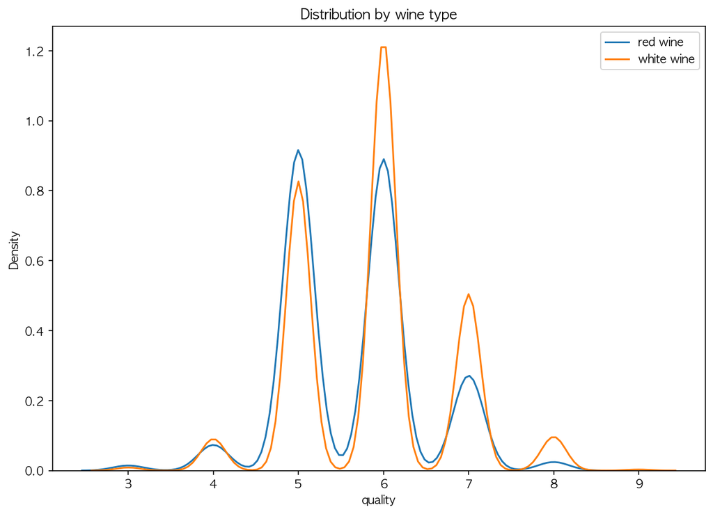

```python
all_df = pd.concat([X, y], 1)

plt.subplots(figsize=(10, 7))
# KDE plot
sns.kdeplot(all_df.loc[all_df['Red'] == 1, "quality"], label='red wine')
sns.kdeplot(all_df.loc[all_df['Red'] == 0, 'quality'], label='white wine')

# # Labeling of plot
plt.xlabel('quality')
plt.ylabel('Density')
plt.title('Distribution by wine type')

plt.show()
```

#### 스케일링

```python
from sklearn.linear_model import LinearRegression
from sklearn.preprocessing import MinMaxScaler, StandardScaler, RobustScaler

rb = RobustScaler()
X[X.columns] = rb.fit_transform(X)
```

#### 회귀모델

(1) intercept 포함

```python
#### 인터셉트 포함할때
X = sm.add_constant(X)
model = sm.OLS(y, X)
result = model.fit()
result.summary()
```

OLS Regression Results

| Dep. Variable: | quality | R-squared: | 0.303 |
| --- | --- | --- | --- |
| Model: | OLS | Adj. R-squared: | 0.301 |
| Method: | Least Squares | F-statistic: | 230.0 |
| Date: | Tue, 09 Jun 2020 | Prob (F-statistic): | 0.00 |
| Time: | 17:05:33 | Log-Likelihood: | -6997.7 |
| No. Observations: | 6370 | AIC: | 1.402e+04 |
| Df Residuals: | 6357 | BIC: | 1.411e+04 |
| Df Model: | 12 |  |  |
| Covariance Type: | nonrobust |  |  |

|  | coef | std err | t | P>\|t\| | [0.025 | 0.975] |
| --- | --- | --- | --- | --- | --- | --- |
| const | 5.5053 | 0.031 | 179.636 | 0.000 | 5.445 | 5.565 |
| fixed acidity | 0.1388 | 0.022 | 6.293 | 0.000 | 0.096 | 0.182 |
| volatile acidity | -0.2539 | 0.014 | -18.218 | 0.000 | -0.281 | -0.227 |
| citric acid | -0.0128 | 0.011 | -1.135 | 0.257 | -0.035 | 0.009 |
| residual sugar | 0.4293 | 0.040 | 10.607 | 0.000 | 0.350 | 0.509 |
| chlorides | -0.0173 | 0.009 | -1.979 | 0.048 | -0.034 | -0.000 |
| free sulfur dioxide | 0.1670 | 0.020 | 8.303 | 0.000 | 0.128 | 0.206 |
| total sulfur dioxide | -0.0961 | 0.026 | -3.629 | 0.000 | -0.148 | -0.044 |
| density | -0.5784 | 0.075 | -7.694 | 0.000 | -0.726 | -0.431 |
| pH | 0.1201 | 0.020 | 6.092 | 0.000 | 0.081 | 0.159 |
| sulphates | 0.1217 | 0.013 | 9.318 | 0.000 | 0.096 | 0.147 |
| alcohol | 0.3684 | 0.036 | 10.105 | 0.000 | 0.297 | 0.440 |
| Red | 0.4558 | 0.062 | 7.340 | 0.000 | 0.334 | 0.578 |

| Omnibus: | 107.690 | Durbin-Watson: | 1.630 |
| --- | --- | --- | --- |
| Prob(Omnibus): | 0.000 | Jarque-Bera (JB): | 197.465 |
| Skew: | 0.099 | Prob(JB): | 1.32e-43 |
| Kurtosis: | 3.839 | Cond. No. | 20.6 |

Warnings:  
[1] Standard Errors assume that the covariance matrix of the errors is correctly specified.

```python
print("TSS = ", result.centered_tss)
print("ESS = ", result.ess)
print("RSS = ", result.ssr)
print("ESS + RSS = ", result.ess + result.ssr)
print("R squared = ", result.rsquared)
```

```
TSS =  4813.181161695447
ESS =  1457.0543818235806
RSS =  3356.126779871867
ESS + RSS =  4813.181161695447
R squared =  0.3027216996150487
```

(2) intercept 미포함

```python
#### 인터셉트가 없을 때
X.drop("const", 1, inplace = True)

model = sm.OLS(y, X)
result = model.fit()
result.summary()
```

OLS Regression Results

| Dep. Variable: | quality | R-squared (uncentered): | 0.908 |
| --- | --- | --- | --- |
| Model: | OLS | Adj. R-squared (uncentered): | 0.908 |
| Method: | Least Squares | F-statistic: | 5211. |
| Date: | Tue, 09 Jun 2020 | Prob (F-statistic): | 0.00 |
| Time: | 17:05:34 | Log-Likelihood: | -12745. |
| No. Observations: | 6370 | AIC: | 2.551e+04 |
| Df Residuals: | 6358 | BIC: | 2.559e+04 |
| Df Model: | 12 |  |  |
| Covariance Type: | nonrobust |  |  |

|  | coef | std err | t | P>\|t\| | [0.025 | 0.975] |
| --- | --- | --- | --- | --- | --- | --- |
| fixed acidity | 2.7114 | 0.041 | 65.593 | 0.000 | 2.630 | 2.792 |
| volatile acidity | -0.2056 | 0.034 | -5.985 | 0.000 | -0.273 | -0.138 |
| citric acid | 0.1592 | 0.028 | 5.758 | 0.000 | 0.105 | 0.213 |
| residual sugar | 6.9907 | 0.043 | 162.658 | 0.000 | 6.906 | 7.075 |
| chlorides | 0.1581 | 0.021 | 7.392 | 0.000 | 0.116 | 0.200 |
| free sulfur dioxide | -0.2921 | 0.049 | -5.941 | 0.000 | -0.388 | -0.196 |
| total sulfur dioxide | 1.3041 | 0.062 | 20.911 | 0.000 | 1.182 | 1.426 |
| density | -12.4734 | 0.088 | -142.198 | 0.000 | -12.645 | -12.301 |
| pH | 2.0105 | 0.041 | 48.920 | 0.000 | 1.930 | 2.091 |
| sulphates | 0.5549 | 0.032 | 17.533 | 0.000 | 0.493 | 0.617 |
| alcohol | -4.1825 | 0.065 | -64.724 | 0.000 | -4.309 | -4.056 |
| Red | 8.5821 | 0.105 | 81.856 | 0.000 | 8.377 | 8.788 |

| Omnibus: | 331.577 | Durbin-Watson: | 1.387 |
| --- | --- | --- | --- |
| Prob(Omnibus): | 0.000 | Jarque-Bera (JB): | 1291.138 |
| Skew: | -0.007 | Prob(JB): | 4.29e-281 |
| Kurtosis: | 5.206 | Cond. No. | 9.63 |

Warnings:  
[1] Standard Errors assume that the covariance matrix of the errors is correctly specified.

```python
print("TSS = ", result.centered_tss)
print("ESS = ", result.ess)
print("RSS = ", result.ssr)
print("ESS + RSS = ", result.ess + result.ssr)
print("R squared = ", result.rsquared)
```

```
TSS =  4813.181161695447
ESS =  200567.702995477
RSS =  20392.297004522996
ESS + RSS =  220960.0
R squared =  0.9077104588861197
```

1.4 Linear Regression 으로 예측모형을 만들어보고, 모델에 대한 성과평가를 해보시오 (회귀분석에서 모델의 성능평가에 쓰이는 대표적인 지표는?), Cross validation 은 모델 평가에 어떻게 활용되는지 자유롭게 기술하시오.

### Answer

#### 1.4.1 측정지표 관련 Discussion

#### $R^2$

회귀모델에서 가장 널리 쓰이는 metric은 $R^2$이며, coefficient of determination으로도 알려져 있습니다. (공식은 아래 참조)

$$R^2(y, \hat{y}) = 1 - \frac{\sum_0^{n-1} (y_i - \hat{y}_i)^2}{\sum_0^{n-1}(y_i - \bar{y})^2}$$

$R^2$은 샘플들이 모델에 의해 얼마나 잘 예측되어질 것인가를 보여주며 best score는 1이다. Average로 예측하면 score는 0이 나오며, 이보다 성능이 나쁠경우 negative값이 나옵니다

#### Residual Sum of Squares (RSS)

잔차제곱합 RSS(residual sum of squares)은 관측 값과 예측값 사이의 거리 (잔차)를 제곱 한 후 모두 합하며 보통 최소 제곱 회귀 분석은 이 값을 최소화하도록 설계됩니다. RSS는 여러 잔차들의 합이므로 단독으로 해석할수가 없지만 회귀 분석이 매우 중요하기 때문에 통계적 적합 검정에 종종 포함됩니다.

$$\text{RSS} = \sum_0^{n - 1} (y_i - \hat{y}_i)^2$$

#### Mean Squared Error (MSE)

MSE는 RSS의 해석가능한 버젼이라고 보면 됩니다. MSE는 RSS를 집합의 샘플 수로 나눠줘서 모델의 평균 제곱 오차를 구합니다. MSE는 비교적 쉽게 해석할 수 있다는 장점이 있지만, 공식에 제곱을 해주는 부분으로 인해 아웃라이어에 취약한 부분도 있다는 단점이 있습니다.

$$\text{MSE} = \frac{1}{n} \cdot \sum_0^{n - 1} (y_i - \hat{y}_i)^2$$

#### Mean Absolute Error

MAE는 예상되는 절대 오차를 계산합니다. 잔차제곱이 아닌 평균을 포함하기 때문에 MSE보다 outlier에 더 resistant하다는 장점이 있습니다.

$$\text{MAE}(y, \hat{y}) = \frac{1}{n}\sum_0^{n-1} | y_i - \hat{y}_i |$$

#### Median Absolute Error

the median absolute error는 단순히 절대값이 아니라 중앙값(median)을 취하기 때문에 outlier에 가장 roubust한 측면이 있습니다.

$$\text{Mean Absolute Error} = \text{median}(|y_0 - \hat{y}_0, \ldots, |y_n - \hat{y}_n|)$$

#### Root mean squared error (RMSE)

RMSE는 MAE 평균 절대 오차와 직접 비교할 수 있고 비슷한 역할을합니다.

계산 효과는 RMSE가 이상치에 대한 내성이 적으므로 이상치가 제대로 handling되지 않은 경우 적합하지 않은 결과가 나올 수 있습니다. 따라서 하이퍼파라미터 searching과 같은 작업을 할 때는 좋은 점이 있습니다. 그러나 MAE는 해석이 가능하고 RMSE는 그렇지 않기 때문에 MAE가 Reporting 측면에서는 좀더 유용하게 쓰이는 경향이 있습니다,

$$\text{RMSE} = \sqrt{\text{MSE}} = \sqrt{\frac{1}{n}\sum_0^{n - 1} (y_i - \hat{y}_i)^2}$$

그럼에도 일반적으로 분산 대신 표준오차를 사용하듯 MSE 대신 RMSE를 많이 사용하며, 주로 사용되는 측정 지표중에 하나입니다.

#### 1.4.2 Cross Validation Discussion

고정된 train set과 test set으로 평가를 하고, 반복적으로 모델을 튜닝하다보면 test set에만 과적합되어버리는 결과가 생기는데 이를 해결하고자 하는 것이 바로 교차 검증(cross validation)입니다.

전체 데이터 셋을 k개의 subset으로 나누고 k번의 평가를 실행하는데, 이 때 test set을 중복 없이 바꾸어가면서 평가를 진행합니다.

다음으로 k개의 평가 지표(이 경우는 accuracy로 예를 듦)를 평균(때에 따라 평균이 아닌 방법을 사용할 수도 있음)내어서 최종적으로 모델의 성능을 평가한다. 이것이 교차 검증의 과정입니다.

장점 :

- 모든 데이터 셋을 평가에 활용할 수 있다.
- 평가에 사용되는 데이터 편중을 막을 수 있다.
- 평가 결과에 따라 좀 더 일반화된 모델을 만들 수 있다.
- 모든 데이터 셋을 훈련에 활용할 수 있다.
- 정확도를 향상시킬 수 있다.
- 데이터 부족으로 인한 underfitting을 방지할 수 있다.

단점 :

- Iteration 횟수가 많기 때문에 모델 훈련/평가 시간이 오래 걸린다.

#### 1.4.3 예측모델결과 Discussion

예측모델을 시행 결과

k_fold 5의 Cross Validation

#### Hold-out과 Cross-Validation 수행결과 비슷한 예측결과를 보였음. feature selection 등을 통해 좀 더 다양한 추가 테스트가 필요할 것으로 보임

- [모델결과는 아래 참조]

#### Data Scaling시 주의. fit 메서드는 학습용 데이터에만 적용!! 그 후, transform 메서드를 학습용 데이터와 테스트 데이터에 적용한다.

```python
all_df = pd.concat([red, white], 0)

y = all_df["quality"]
X = all_df.drop("quality", 1)
```

```python
from sklearn.model_selection import train_test_split

X_train, X_test, y_train, y_test = train_test_split(X, y, test_size = 0.3, random_state = 42)
```

```python
X_train.shape, X_test.shape, y_train.shape, y_test.shape
```

```
((4459, 12), (1911, 12), (4459,), (1911,))
```

#### Scaling 적용

```python
rb = RobustScaler()
X_train[X_train.columns] = rb.fit_transform(X_train)
X_test[X_test.columns] = rb.transform(X_test)
```

#### Linear Regression모델 예측

```python
from sklearn.linear_model import LinearRegression

lr = LinearRegression()

lr.fit(X_train, y_train)
preds = lr.predict(X_test)

print("mse ", mean_squared_error(y_test, preds))
print("rmse = ", np.sqrt(mse))
print("r2 = ", r2_score(y_test, preds))
```

[output not shown]

#### Cross Validation

```python
from sklearn.model_selection import KFold
from sklearn.model_selection import cross_val_score, cross_val_predict

k_fold = 5

score = cross_val_score(lr, X_train, y_train, cv=k_fold)
score = score.mean()
print("Score= {0:.5f}".format(score))
```

```
Score= 0.29961
```

```python
preds = cross_val_predict(lr,
                          X_test,
                          y_test,
                          cv=k_fold)

print("mse ", mean_squared_error(y_test, preds))
print("rmse = ", np.sqrt(mse))
print("r2 = ", r2_score(y_test, preds))
```

[output not shown]

#### Practice 2: Ridge, LASSO Regression

다음 실습은 Practice 1 번의 Wine data 분석에 이어서 Ridge, LASSO Regression 을 해보며, 정규화(Regularization)의 효과에 대해 분석해보는 것이 주 목적입니다. 해당 개념을 숙지하는 것을 주목적입니다. 아래 질문에 답해 주세요.

2.1. 정규화(Regularization)를 왜 하는지에 대한 이유를 2 가지 이상 설명하시오.

2.2. Ridge 와 LASSO 의 정규화 방법에 있어서 차이점을 설명하시오.

2.3. Red wine 과 White wine 데이터 두 개를 하나로 묶어서 (예 : Wine type 을 red (1) 와 white (0)으로 나누고 Dummy code 를 부여) 데이터를 구성한 다음, Lasso Regression 분석을 시행하시오 (예 : [분석]-[회귀분석]-[범주형 회귀] 메뉴를 활용하시오).

2.4. Red wine 과 White wine 데이터 두 개를 하나로 묶어서 (예 : Wine type 을 red (1) 와 white (0)으로 나누고 Dummy code 를 부여) 데이터를 구성한 다음, Ridge Regression 분석을 시행하시오 (예 : [분석]-[회귀분석]-[범주형 회귀] 메뉴를 활용하시오).

### Answer

#### 2.1

정규화(regularized) 선형회귀 방법은 선형회귀 계수(weight)에 대한 제약 조건을 추가함으로써 모형이 과도하게 최적화되는 현상, 즉 과최적화를 막는 방법입니다. Regularized Method, Penalized Method, Contrained Least Squares 이라고도 불립니다.

모형이 과도하게 최적화되면 모형 계수의 크기도 과도하게 증가하는 경향이 나타납니다. 따라서 정규화 방법에서 추가하는 제약 조건은 일반적으로 계수의 크기를 제한하는 방법입니다. 일반적으로 다음과 같은 세가지 방법이 사용됩니다.

- Ridge / Lasso / Elastic Net 회귀모형

또한 독립변수들간에 다중공선성이 발생하는 문제를 방지를 위해서도 사용됩니다.

2.2. Ridge 와 LASSO 의 정규화 방법에 있어서 차이점을 설명하시오.

### Answer

##### Least Squares Linear

$$ y= w_{1} * x_{1} + w_{2} * x_{2} +……+w_{10} * x_{10}\tag7$$$$ f(x)=\sum_{i=1}^{m}w_i x_i =w^Tx \tag1$$

일반적인 회귀방법에서 비용함수는 MSE를 최소화하는 방향으로 나아가게 됨. 일반적인 회귀방법에서 데이터의 feature가 많아질수록 overfitting이 발생할 가능성도 높아지는데 정규화는 이를 막기 위해 MSE + penalty(regular-term)으로 비용함수를 재정의함. 비용함수에 regular-term이 추가되면서 비용함수 최소화를 진행에 따라 가중치가 낮은 항들이 0 또는 0에 가까운 수로 수렴되어 모델에 미치는 영향이 제한되록 하여 오버피팅, 다중공선성 등의 리스크를 낮추는 방법임

##### Lasso Regression

$$F_{LASSO} = {\left \| y-Xw \right \|_{2}}^{2} + \lambda{\left \| w \right \|_{1}} \tag{12}$$

**L1 정규화는 계수의 절대 값의 합과 같은 페널티를 추가함.** 일부 파라미터를 0으로 줄여서 일부 변수가 모형에서 아무런 역할을하지 않으므로 일종의 L1 회귀 분석은 모형에서 feature selection역할을 한다고 볼 수 있음.

람다가 커질수록 더 많은 계수가 줄어들며 람다가 증가함에 따라 변수가 남아 있지 않을 때까지 계수가 하나씩 cut됨.

처음에는 절삭 계수가 모델의 오버 피팅 및 일반화 기능을 줄여서 테스트 오류가 감소하지만 점점 더 많은 계수들을 절삭할수록 어느 시점에서는 실제로 필요한 변수들이 삭제되면서 테스트 오류가 증가되는 양상을 보임

##### Ridge Regression

$$F_{Ridge}=\sum_{i=1}^{n}(y_{i}-w^Tx)^2 + \lambda \sum_{i=1}^{n}(w_{i})^2 \tag8$$

**L2 정규화는 계수의 제곱 값의 합만큼의 페널티를 추가함.** L2 정규화는 파라미터를 상대적으로 작게만들며, 페널티가 클수록 계수가 더 작아지도록 강제함.

L1 정규화와 비교하면 계수가 점차적으로 완만하게 감소하고 0으로 완전히 절삭되진 않는 특징이 있음.

##### ElasticNet

**Elastic-net은 L1과 L2 정규화 가 혼합 된 것으로 알파(alpha)값이 Elastic Net 정규화에서 L1과 L2 정규화 사이의 비율을 설정하는 일종의 하이브리드 형태의 모델임** 람다값이 증가할 경우 계수는 라쏘와 같이 0으로 수렴하지만, 라쏘보다 완만하게 진행되는 특징있음

2.3. Red wine 과 White wine 데이터 두 개를 하나로 묶어서 (예 : Wine type 을 red (1) 와 white (0)으로 나누고 Dummy code 를 부여) 데이터를 구성한 다음, Lasso Regression 분석을 시행하시오 (예 : [분석]-[회귀분석]-[범주형 회귀] 메뉴를 활용하시오).

2.4. Red wine 과 White wine 데이터 두 개를 하나로 묶어서 (예 : Wine type 을 red (1) 와 white (0)으로 나누고 Dummy code 를 부여) 데이터를 구성한 다음, Ridge Regression 분석을 시행하시오 (예 : [분석]-[회귀분석]-[범주형 회귀] 메뉴를 활용하시오).

### 라쏘 모델

```python
from sklearn import linear_model
model = linear_model.Lasso(alpha=0.001)

model.fit(X, y)
preds = model.predict(X)

print("mse ", mean_squared_error(y, preds))
print("rmse = ", np.sqrt(mse))
print("r2 = ", model.score(X, y))
model.coef_
```

[output not shown]

### Ridge 모델

```python
from sklearn import linear_model
model = linear_model.Ridge(alpha=0.5)

model.fit(X, y)
preds = model.predict(X)

print("mse ", mean_squared_error(y, preds))
print("rmse = ", np.sqrt(mse))
print("r2 = ", model.score(X, y))
model.coef_
```

[output not shown]

### 엘라스틱넷

```python
model = linear_model.ElasticNet(alpha=0.001)

model.fit(X, y)
preds = model.predict(X)

print("mse ", mean_squared_error(y, preds))
print("rmse = ", np.sqrt(mse))
print("r2 = ", model.score(X, y))
model.coef_
```

[output not shown]

##### 참고) statsmodel

- Lasso 모형

```python
# 모수 L1_wt가 0 이면 순수 Ridge 모형, L1_wt가 1 이면
# 순수 Lasso 모형, 모수 L1_wt가 0과 1 사이이면 Elastic Net 모형이 된다.
X = sm.add_constant(X)
model = sm.OLS(y, X)
result = model.fit_regularized(alpha=0.001, L1_wt=1)

print(result.params)
print(r2_score(y, result.predict(X)))
print(mean_squared_error(y, result.predict(X)))
```

```
const                   5.571129
fixed acidity           0.097944
volatile acidity       -0.250735
citric acid            -0.011800
residual sugar          0.340020
chlorides              -0.018594
free sulfur dioxide     0.167527
total sulfur dioxide   -0.107525
density                -0.410007
pH                      0.090387
sulphates               0.114851
alcohol                 0.436071
Red                     0.353768
dtype: float64
```

- Ridge 모형

```python
X = sm.add_constant(X)
model = sm.OLS(y, X)
result = model.fit_regularized(alpha=0.001, L1_wt=0)

print(result.params)
print(r2_score(y, result.predict(X)))
print(mean_squared_error(y, result.predict(X)))
```

[output not shown]

- 엘라스틱넷

```python
X = sm.add_constant(X)
model = sm.OLS(y, X)
result = model.fit_regularized(alpha=0.001, L1_wt=0.3)

print(result.params)
print(r2_score(y, result.predict(X)))
print(mean_squared_error(y, result.predict(X)))
```

```
const                   5.523947
fixed acidity           0.122912
volatile acidity       -0.251918
citric acid            -0.011835
residual sugar          0.399070
chlorides              -0.017662
free sulfur dioxide     0.167816
total sulfur dioxide   -0.100504
density                -0.517188
pH                      0.108879
sulphates               0.119784
alcohol                 0.394403
Red                     0.422843
dtype: float64
```

# Practice 3: Logistic Regression

Data: Churn Data

Question)

다음 실습은 Telco 통신사 고객들의 데이터로, 고객의 여러 특성과 해당 고객이 해당 통신사를 이탈했는지 여부가 데이터로 주어져 있습니다. 고객들의 여러 특성과 고객 이탈 여부 간 Logistic Regression 모형을 만들어보고 해석해보는 것이 주 목적입니다. 아래 질문에 답해 주세요.

3.1. Linear Regression 모형이 아닌 Logistic Regression 이 분석에 더 적합한 이유를 간략하게 설명하시오. (힌트: 종속변수)

3.2. 모든 변수를 이용해서 고객 이탈 예측 모형을 Logistic Regression 을 사용해서 만드시오.

3.3. 각 계수들에 대해 유의성을 판단하고 해석하시오. 그리고 유의한 회귀계수 값을 이용하여, 독립변수와 종속변수의 관계를 승산비 (Odds ratio)를 통해 해석하시오.

3.4 가장 이탈할 가능성이 높은 고객은 어떤 특성을 가지고 있는지 기술하고 이를 바탕으로 고객 유지 전략에 대해 간략히 제안해보시오

3.5. ROC Curve 를 구해 보시오. 이를 해석해보고 모형에 대한 평가를 해보시오.

#### 로지스틱 리그레션 참조자료

- https://ratsgo.github.io/machine%20learning/2017/04/02/logistic/
- 사이킷런 http://hleecaster.com/ml-logistic-regression-example/
- odd ratio https://m.blog.naver.com/PostView.nhn?blogId=samsjang&logNo=220968297927&proxyReferer=https:%2F%2Fwww.google.com%2F

#### 엑셀파일 불러오기

```python
df = pd.read_csv("desktop/Churn.csv")
df.head()
```

|  | customerID | gender | SeniorCitizen | Partner | Dependents | tenure | PhoneService | MultipleLines | InternetService | OnlineSecurity | OnlineBackup | DeviceProtection | TechSupport | StreamingTV | StreamingMovies | Contract | PaperlessBilling | PaymentMethod | MonthlyCharges | TotalCharges | Churn |
| --- | --- | --- | --- | --- | --- | --- | --- | --- | --- | --- | --- | --- | --- | --- | --- | --- | --- | --- | --- | --- | --- |
| 0 | 7590-VHVEG | Female | 0 | Yes | No | 1 | No | No phone service | DSL | No | Yes | No | No | No | No | Month-to-month | Yes | Electronic check | 29.85 | 29.85 | No |
| 1 | 5575-GNVDE | Male | 0 | No | No | 34 | Yes | No | DSL | Yes | No | Yes | No | No | No | One year | No | Mailed check | 56.95 | 1889.5 | No |
| 2 | 3668-QPYBK | Male | 0 | No | No | 2 | Yes | No | DSL | Yes | Yes | No | No | No | No | Month-to-month | Yes | Mailed check | 53.85 | 108.15 | Yes |
| 3 | 7795-CFOCW | Male | 0 | No | No | 45 | No | No phone service | DSL | Yes | No | Yes | Yes | No | No | One year | No | Bank transfer (automatic) | 42.30 | 1840.75 | No |
| 4 | 9237-HQITU | Female | 0 | No | No | 2 | Yes | No | Fiber optic | No | No | No | No | No | No | Month-to-month | Yes | Electronic check | 70.70 | 151.65 | Yes |

#### 데이터타입 확인

```python
df.dtypes
```

```
customerID           object
gender               object
SeniorCitizen         int64
Partner              object
Dependents           object
tenure                int64
PhoneService         object
MultipleLines        object
InternetService      object
OnlineSecurity       object
OnlineBackup         object
DeviceProtection     object
TechSupport          object
StreamingTV          object
StreamingMovies      object
Contract             object
PaperlessBilling     object
PaymentMethod        object
MonthlyCharges      float64
TotalCharges         object
Churn                object
dtype: object
```

ToalCharges가 숫자형인데 object로 되어 있으므로 정정해 준다

- TotalCharges 안에 " " 값을 NA로 대체해주고 제거해준다.

```python
df["TotalCharges"] = df["TotalCharges"].replace(" ", np.nan)
```

```python
df["TotalCharges"].isna().mean()
```

```
0.001561834445548772
```

```python
# 0.0015로 작은 portion이므로 NA 제거 이후에, 해당 변수를 float형태로 전환해주었다
df = df.dropna()
df["TotalCharges"] = df["TotalCharges"].astype("float")
```

```python
# 기본통계 확인
df.describe()
```

|  | SeniorCitizen | tenure | MonthlyCharges | TotalCharges |
| --- | --- | --- | --- | --- |
| count | 7032.000000 | 7032.000000 | 7032.000000 | 7032.000000 |
| mean | 0.162400 | 32.421786 | 64.798208 | 2283.300441 |
| std | 0.368844 | 24.545260 | 30.085974 | 2266.771362 |
| min | 0.000000 | 1.000000 | 18.250000 | 18.800000 |
| 25% | 0.000000 | 9.000000 | 35.587500 | 401.450000 |
| 50% | 0.000000 | 29.000000 | 70.350000 | 1397.475000 |
| 75% | 0.000000 | 55.000000 | 89.862500 | 3794.737500 |
| max | 1.000000 | 72.000000 | 118.750000 | 8684.800000 |

```python
# 백업데이터 생성
df_original = df.copy()
```

#### customerID 제거

불필요한 customerID 컬럼은 제거해준다

```python
df.drop("customerID", 1, inplace = True)
```

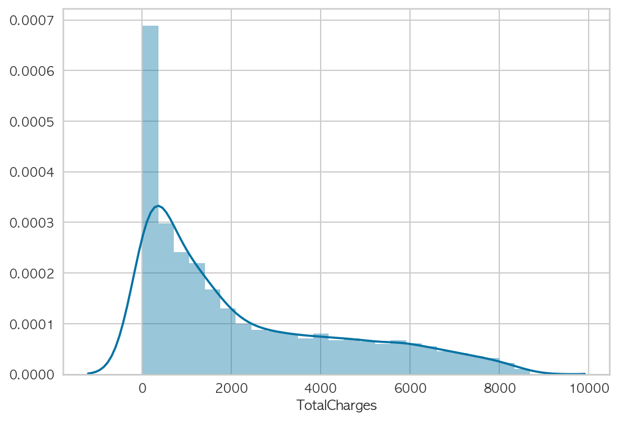

```python
sns.distplot(df["TotalCharges"])
```

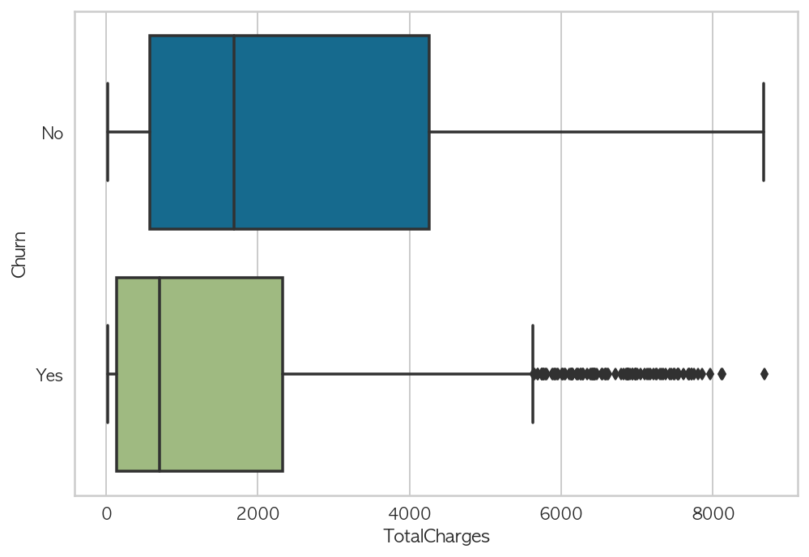

```python
sns.boxplot(data = df, x = "TotalCharges", y = "Churn")
```

#### 범주형 변수들을 레이블 인코딩 해준다

```python
#바이너리 컬럼 변환

binary = ['PhoneService', 'PaperlessBilling', 'Churn', 'Partner', 'Dependents']


def b(x):
    return x.map({'Yes': 1, "No": 0})


df[binary] = df[binary].apply(b)
```

```python
# 'Contract', 'PaymentMethod', 'InternetService', 'gender'에 대한 K-1 더미생성
df1 = pd.get_dummies(
    df,
    columns=['Contract', 'PaymentMethod', 'InternetService', 'gender'],
    drop_first=True)
```

```python
df1
```

|  | SeniorCitizen | Partner | Dependents | tenure | PhoneService | MultipleLines | OnlineSecurity | OnlineBackup | DeviceProtection | TechSupport | StreamingTV | StreamingMovies | PaperlessBilling | MonthlyCharges | TotalCharges | Churn | Contract_One year | Contract_Two year | PaymentMethod_Credit card (automatic) | PaymentMethod_Electronic check | PaymentMethod_Mailed check | InternetService_Fiber optic | InternetService_No | gender_Male |
| --- | --- | --- | --- | --- | --- | --- | --- | --- | --- | --- | --- | --- | --- | --- | --- | --- | --- | --- | --- | --- | --- | --- | --- | --- |
| 0 | 0 | 1 | 0 | 1 | 0 | No phone service | No | Yes | No | No | No | No | 1 | 29.85 | 29.85 | 0 | 0 | 0 | 0 | 1 | 0 | 0 | 0 | 0 |
| 1 | 0 | 0 | 0 | 34 | 1 | No | Yes | No | Yes | No | No | No | 0 | 56.95 | 1889.50 | 0 | 1 | 0 | 0 | 0 | 1 | 0 | 0 | 1 |
| 2 | 0 | 0 | 0 | 2 | 1 | No | Yes | Yes | No | No | No | No | 1 | 53.85 | 108.15 | 1 | 0 | 0 | 0 | 0 | 1 | 0 | 0 | 1 |
| 3 | 0 | 0 | 0 | 45 | 0 | No phone service | Yes | No | Yes | Yes | No | No | 0 | 42.30 | 1840.75 | 0 | 1 | 0 | 0 | 0 | 0 | 0 | 0 | 1 |
| 4 | 0 | 0 | 0 | 2 | 1 | No | No | No | No | No | No | No | 1 | 70.70 | 151.65 | 1 | 0 | 0 | 0 | 1 | 0 | 1 | 0 | 0 |
| ... | ... | ... | ... | ... | ... | ... | ... | ... | ... | ... | ... | ... | ... | ... | ... | ... | ... | ... | ... | ... | ... | ... | ... | ... |
| 7038 | 0 | 1 | 1 | 24 | 1 | Yes | Yes | No | Yes | Yes | Yes | Yes | 1 | 84.80 | 1990.50 | 0 | 1 | 0 | 0 | 0 | 1 | 0 | 0 | 1 |
| 7039 | 0 | 1 | 1 | 72 | 1 | Yes | No | Yes | Yes | No | Yes | Yes | 1 | 103.20 | 7362.90 | 0 | 1 | 0 | 1 | 0 | 0 | 1 | 0 | 0 |
| 7040 | 0 | 1 | 1 | 11 | 0 | No phone service | Yes | No | No | No | No | No | 1 | 29.60 | 346.45 | 0 | 0 | 0 | 0 | 1 | 0 | 0 | 0 | 0 |
| 7041 | 1 | 1 | 0 | 4 | 1 | Yes | No | No | No | No | No | No | 1 | 74.40 | 306.60 | 1 | 0 | 0 | 0 | 0 | 1 | 1 | 0 | 1 |
| 7042 | 0 | 0 | 0 | 66 | 1 | No | Yes | No | Yes | Yes | Yes | Yes | 1 | 105.65 | 6844.50 | 0 | 0 | 1 | 0 | 0 | 0 | 1 | 0 | 1 |

7032 rows × 24 columns

```python
category = df1.columns[df1.dtypes == "object"]
```

```python
# 나머지 카테고리형 변수들에 대한 더미 생성
df1 = pd.get_dummies(df1, columns=category)
df1
```

|  | SeniorCitizen | Partner | Dependents | tenure | PhoneService | PaperlessBilling | MonthlyCharges | TotalCharges | Churn | Contract_One year | Contract_Two year | PaymentMethod_Credit card (automatic) | PaymentMethod_Electronic check | PaymentMethod_Mailed check | InternetService_Fiber optic | InternetService_No | gender_Male | MultipleLines_No | MultipleLines_No phone service | MultipleLines_Yes | OnlineSecurity_No | OnlineSecurity_No internet service | OnlineSecurity_Yes | OnlineBackup_No | OnlineBackup_No internet service | OnlineBackup_Yes | DeviceProtection_No | DeviceProtection_No internet service | DeviceProtection_Yes | … |
| --- | --- | --- | --- | --- | --- | --- | --- | --- | --- | --- | --- | --- | --- | --- | --- | --- | --- | --- | --- | --- | --- | --- | --- | --- | --- | --- | --- | --- | --- | --- |
| 0 | 0 | 1 | 0 | 1 | 0 | 1 | 29.85 | 29.85 | 0 | 0 | 0 | 0 | 1 | 0 | 0 | 0 | 0 | 0 | 1 | 0 | 1 | 0 | 0 | 0 | 0 | 1 | 1 | 0 | 0 | … |
| 1 | 0 | 0 | 0 | 34 | 1 | 0 | 56.95 | 1889.50 | 0 | 1 | 0 | 0 | 0 | 1 | 0 | 0 | 1 | 1 | 0 | 0 | 0 | 0 | 1 | 1 | 0 | 0 | 0 | 0 | 1 | … |
| 2 | 0 | 0 | 0 | 2 | 1 | 1 | 53.85 | 108.15 | 1 | 0 | 0 | 0 | 0 | 1 | 0 | 0 | 1 | 1 | 0 | 0 | 0 | 0 | 1 | 0 | 0 | 1 | 1 | 0 | 0 | … |
| 3 | 0 | 0 | 0 | 45 | 0 | 0 | 42.30 | 1840.75 | 0 | 1 | 0 | 0 | 0 | 0 | 0 | 0 | 1 | 0 | 1 | 0 | 0 | 0 | 1 | 1 | 0 | 0 | 0 | 0 | 1 | … |
| 4 | 0 | 0 | 0 | 2 | 1 | 1 | 70.70 | 151.65 | 1 | 0 | 0 | 0 | 1 | 0 | 1 | 0 | 0 | 1 | 0 | 0 | 1 | 0 | 0 | 1 | 0 | 0 | 1 | 0 | 0 | … |
| ... | ... | ... | ... | ... | ... | ... | ... | ... | ... | ... | ... | ... | ... | ... | ... | ... | ... | ... | ... | ... | ... | ... | ... | ... | ... | ... | ... | ... | ... | … |
| 7038 | 0 | 1 | 1 | 24 | 1 | 1 | 84.80 | 1990.50 | 0 | 1 | 0 | 0 | 0 | 1 | 0 | 0 | 1 | 0 | 0 | 1 | 0 | 0 | 1 | 1 | 0 | 0 | 0 | 0 | 1 | … |
| 7039 | 0 | 1 | 1 | 72 | 1 | 1 | 103.20 | 7362.90 | 0 | 1 | 0 | 1 | 0 | 0 | 1 | 0 | 0 | 0 | 0 | 1 | 1 | 0 | 0 | 0 | 0 | 1 | 0 | 0 | 1 | … |
| 7040 | 0 | 1 | 1 | 11 | 0 | 1 | 29.60 | 346.45 | 0 | 0 | 0 | 0 | 1 | 0 | 0 | 0 | 0 | 0 | 1 | 0 | 0 | 0 | 1 | 1 | 0 | 0 | 1 | 0 | 0 | … |
| 7041 | 1 | 1 | 0 | 4 | 1 | 1 | 74.40 | 306.60 | 1 | 0 | 0 | 0 | 0 | 1 | 1 | 0 | 1 | 0 | 0 | 1 | 1 | 0 | 0 | 1 | 0 | 0 | 1 | 0 | 0 | … |
| 7042 | 0 | 0 | 0 | 66 | 1 | 1 | 105.65 | 6844.50 | 0 | 0 | 1 | 0 | 0 | 0 | 1 | 0 | 1 | 1 | 0 | 0 | 0 | 0 | 1 | 1 | 0 | 0 | 0 | 0 | 1 | … |

7032 rows × 38 columns

```python
df1.shape
```

```
(7032, 38)
```

```python
# 컬럼들간에 서로 연결되어 있는 점을 감안, 다중공선성 문제 해결을 위해 중복 컬럼을 제거해준다.
# Ex) iNternet Service 등에 NO라고 된 답변이 다른 컬럼들에도 영향을 미침

drop_list = []
for i in df1.columns:
    if "_No internet service" in i:
        drop_list.append(i)

df1.drop(drop_list, 1, inplace=True)
df1.drop("MultipleLines_No phone service", 1, inplace=True)
```

```python
y = df1.Churn
df1.drop("Churn", 1, inplace=True)
```

#### 스케일링

```python
from sklearn.preprocessing import StandardScaler

rs = StandardScaler()
df1[df1.columns] = rs.fit_transform(df1)
```

```python
df1
```

|  | SeniorCitizen | Partner | Dependents | tenure | PhoneService | PaperlessBilling | MonthlyCharges | TotalCharges | Contract_One year | Contract_Two year | PaymentMethod_Credit card (automatic) | PaymentMethod_Electronic check | PaymentMethod_Mailed check | InternetService_Fiber optic | InternetService_No | gender_Male | MultipleLines_No | MultipleLines_Yes | OnlineSecurity_No | OnlineSecurity_Yes | OnlineBackup_No | OnlineBackup_Yes | DeviceProtection_No | DeviceProtection_Yes | TechSupport_No | TechSupport_Yes | StreamingTV_No | StreamingTV_Yes | StreamingMovies_No | … |
| --- | --- | --- | --- | --- | --- | --- | --- | --- | --- | --- | --- | --- | --- | --- | --- | --- | --- | --- | --- | --- | --- | --- | --- | --- | --- | --- | --- | --- | --- | --- |
| 0 | -0.440327 | 1.035617 | -0.652305 | -1.280248 | -3.056334 | 0.828939 | -1.161694 | -0.994194 | -0.514537 | -0.561364 | -0.525351 | 1.404764 | -0.543604 | -0.886896 | -0.52513 | -1.009430 | -0.963411 | -0.854336 | 1.005419 | -0.633746 | -0.884596 | 1.378330 | 1.128178 | -0.723918 | 1.012594 | -0.639260 | 1.226125 | -0.790186 | 1.236360 | … |
| 1 | -0.440327 | -0.965608 | -0.652305 | 0.064303 | 0.327189 | -1.206361 | -0.260878 | -0.173740 | 1.943495 | -0.561364 | -0.525351 | -0.711863 | 1.839576 | -0.886896 | -0.52513 | 0.990658 | 1.037979 | -0.854336 | -0.994611 | 1.577918 | 1.130460 | -0.725516 | -0.886385 | 1.381372 | 1.012594 | -0.639260 | 1.226125 | -0.790186 | 1.236360 | … |
| 2 | -0.440327 | -0.965608 | -0.652305 | -1.239504 | 0.327189 | 0.828939 | -0.363923 | -0.959649 | -0.514537 | -0.561364 | -0.525351 | -0.711863 | 1.839576 | -0.886896 | -0.52513 | 0.990658 | 1.037979 | -0.854336 | -0.994611 | 1.577918 | -0.884596 | 1.378330 | 1.128178 | -0.723918 | 1.012594 | -0.639260 | 1.226125 | -0.790186 | 1.236360 | … |
| 3 | -0.440327 | -0.965608 | -0.652305 | 0.512486 | -3.056334 | -1.206361 | -0.747850 | -0.195248 | 1.943495 | -0.561364 | -0.525351 | -0.711863 | -0.543604 | -0.886896 | -0.52513 | 0.990658 | -0.963411 | -0.854336 | -0.994611 | 1.577918 | 1.130460 | -0.725516 | -0.886385 | 1.381372 | -0.987563 | 1.564308 | 1.226125 | -0.790186 | 1.236360 | … |
| 4 | -0.440327 | -0.965608 | -0.652305 | -1.239504 | 0.327189 | 0.828939 | 0.196178 | -0.940457 | -0.514537 | -0.561364 | -0.525351 | 1.404764 | -0.543604 | 1.127527 | -0.52513 | -1.009430 | 1.037979 | -0.854336 | 1.005419 | -0.633746 | 1.130460 | -0.725516 | 1.128178 | -0.723918 | 1.012594 | -0.639260 | 1.226125 | -0.790186 | 1.236360 | … |
| ... | ... | ... | ... | ... | ... | ... | ... | ... | ... | ... | ... | ... | ... | ... | ... | ... | ... | ... | ... | ... | ... | ... | ... | ... | ... | ... | ... | ... | ... | … |
| 7038 | -0.440327 | 1.035617 | 1.533025 | -0.343137 | 0.327189 | 0.828939 | 0.664868 | -0.129180 | 1.943495 | -0.561364 | -0.525351 | -0.711863 | 1.839576 | -0.886896 | -0.52513 | 0.990658 | -0.963411 | 1.170500 | -0.994611 | 1.577918 | 1.130460 | -0.725516 | -0.886385 | 1.381372 | -0.987563 | 1.564308 | -0.815578 | 1.265525 | -0.808826 | … |
| 7039 | -0.440327 | 1.035617 | 1.533025 | 1.612573 | 0.327189 | 0.828939 | 1.276493 | 2.241056 | 1.943495 | -0.561364 | 1.903490 | -0.711863 | -0.543604 | 1.127527 | -0.52513 | -1.009430 | -0.963411 | 1.170500 | 1.005419 | -0.633746 | -0.884596 | 1.378330 | -0.886385 | 1.381372 | 1.012594 | -0.639260 | -0.815578 | 1.265525 | -0.808826 | … |
| 7040 | -0.440327 | 1.035617 | 1.533025 | -0.872808 | -3.056334 | 0.828939 | -1.170004 | -0.854514 | -0.514537 | -0.561364 | -0.525351 | 1.404764 | -0.543604 | -0.886896 | -0.52513 | -1.009430 | -0.963411 | -0.854336 | -0.994611 | 1.577918 | 1.130460 | -0.725516 | 1.128178 | -0.723918 | 1.012594 | -0.639260 | 1.226125 | -0.790186 | 1.236360 | … |
| 7041 | 2.271039 | 1.035617 | -0.652305 | -1.158016 | 0.327189 | 0.828939 | 0.319168 | -0.872095 | -0.514537 | -0.561364 | -0.525351 | -0.711863 | 1.839576 | 1.127527 | -0.52513 | 0.990658 | -0.963411 | 1.170500 | 1.005419 | -0.633746 | 1.130460 | -0.725516 | 1.128178 | -0.723918 | 1.012594 | -0.639260 | 1.226125 | -0.790186 | 1.236360 | … |
| 7042 | -0.440327 | -0.965608 | -0.652305 | 1.368109 | 0.327189 | 0.828939 | 1.357932 | 2.012344 | -0.514537 | 1.781374 | -0.525351 | -0.711863 | -0.543604 | 1.127527 | -0.52513 | 0.990658 | 1.037979 | -0.854336 | -0.994611 | 1.577918 | 1.130460 | -0.725516 | -0.886385 | 1.381372 | -0.987563 | 1.564308 | -0.815578 | 1.265525 | -0.808826 | … |

7032 rows × 30 columns

#### 상관계수 테스트

```python
cor = df1.corr()**2
cor.style.background_gradient(cmap="Blues")
```

|  | SeniorCitizen | Partner | Dependents | tenure | PhoneService | PaperlessBilling | MonthlyCharges | TotalCharges | Contract_One year | Contract_Two year | PaymentMethod_Credit card (automatic) | PaymentMethod_Electronic check | PaymentMethod_Mailed check | InternetService_Fiber optic | InternetService_No | gender_Male | MultipleLines_No | MultipleLines_Yes | OnlineSecurity_No | OnlineSecurity_Yes | OnlineBackup_No | OnlineBackup_Yes | DeviceProtection_No | DeviceProtection_Yes | TechSupport_No | TechSupport_Yes | StreamingTV_No | StreamingTV_Yes | StreamingMovies_No | … |
| --- | --- | --- | --- | --- | --- | --- | --- | --- | --- | --- | --- | --- | --- | --- | --- | --- | --- | --- | --- | --- | --- | --- | --- | --- | --- | --- | --- | --- | --- | --- |
| SeniorCitizen | 1.000000 | 0.000288 | 0.044331 | 0.000246 | 0.000070 | 0.024416 | 0.048345 | 0.010488 | 0.002161 | 0.013504 | 0.000593 | 0.029351 | 0.023405 | 0.064986 | 0.033313 | 0.000003 | 0.018599 | 0.020448 | 0.034279 | 0.001488 | 0.007663 | 0.004444 | 0.008912 | 0.003542 | 0.042129 | 0.003670 | 0.002368 | 0.011119 | 0.001169 | … |
| Partner | 0.000288 | 1.000000 | 0.204547 | 0.145856 | 0.000338 | 0.000195 | 0.009570 | 0.101807 | 0.006900 | 0.061174 | 0.006778 | 0.006923 | 0.009399 | 0.000002 | 0.000000 | 0.000002 | 0.016907 | 0.020324 | 0.016743 | 0.020548 | 0.018394 | 0.020121 | 0.021522 | 0.023580 | 0.011854 | 0.014449 | 0.015226 | 0.015496 | 0.013803 | … |
| Dependents | 0.044331 | 0.204547 | 1.000000 | 0.026695 | 0.000001 | 0.012129 | 0.012621 | 0.004180 | 0.004792 | 0.040683 | 0.003737 | 0.022283 | 0.003186 | 0.026929 | 0.019150 | 0.000107 | 0.000547 | 0.000591 | 0.034961 | 0.006526 | 0.018885 | 0.000559 | 0.016398 | 0.000193 | 0.029297 | 0.003976 | 0.009982 | 0.000272 | 0.006122 | … |
| tenure | 0.000246 | 0.145856 | 0.026695 | 1.000000 | 0.000062 | 0.000023 | 0.060941 | 0.682079 | 0.040941 | 0.317871 | 0.054196 | 0.044183 | 0.053908 | 0.000321 | 0.001408 | 0.000028 | 0.104905 | 0.110489 | 0.070749 | 0.107779 | 0.099080 | 0.130421 | 0.099112 | 0.130697 | 0.069888 | 0.105813 | 0.060917 | 0.078548 | 0.063953 | … |
| PhoneService | 0.000070 | 0.000338 | 0.000001 | 0.000062 | 1.000000 | 0.000279 | 0.061520 | 0.012771 | 0.000010 | 0.000020 | 0.000048 | 0.000008 | 0.000020 | 0.084206 | 0.029521 | 0.000056 | 0.099362 | 0.078137 | 0.003428 | 0.008404 | 0.008571 | 0.002718 | 0.005688 | 0.004911 | 0.003036 | 0.009051 | 0.015168 | 0.000457 | 0.012382 | … |
| PaperlessBilling | 0.024416 | 0.000195 | 0.012129 | 0.000023 | 0.000279 | 1.000000 | 0.123855 | 0.024910 | 0.002733 | 0.021398 | 0.000188 | 0.043442 | 0.041608 | 0.106583 | 0.102779 | 0.000142 | 0.023096 | 0.026813 | 0.071606 | 0.000016 | 0.020799 | 0.016143 | 0.027640 | 0.010832 | 0.052842 | 0.001409 | 0.002182 | 0.050284 | 0.003479 | … |
| MonthlyCharges | 0.048345 | 0.009570 | 0.012621 | 0.060941 | 0.061520 | 0.123855 | 1.000000 | 0.423885 | 0.000023 | 0.005366 | 0.000903 | 0.073505 | 0.141804 | 0.619676 | 0.582461 | 0.000190 | 0.114591 | 0.240995 | 0.129759 | 0.087881 | 0.044153 | 0.194948 | 0.029260 | 0.232909 | 0.103213 | 0.114448 | 0.000256 | 0.396482 | 0.000298 | … |
| TotalCharges | 0.010488 | 0.101807 | 0.004180 | 0.682079 | 0.012771 | 0.024910 | 0.423885 | 1.000000 | 0.029094 | 0.128190 | 0.033366 | 0.003653 | 0.086853 | 0.130154 | 0.140534 | 0.000000 | 0.157423 | 0.220001 | 0.004162 | 0.170254 | 0.031554 | 0.260202 | 0.035905 | 0.273405 | 0.007102 | 0.187375 | 0.038866 | 0.265956 | 0.041049 | … |
| Contract_One year | 0.002161 | 0.006900 | 0.004792 | 0.040941 | 0.000010 | 0.002733 | 0.000023 | 0.029094 | 1.000000 | 0.083430 | 0.004568 | 0.012000 | 0.000000 | 0.005900 | 0.001449 | 0.000060 | 0.000003 | 0.000013 | 0.014972 | 0.010132 | 0.012574 | 0.007075 | 0.016910 | 0.010591 | 0.014092 | 0.009266 | 0.008741 | 0.003835 | 0.009334 | … |
| Contract_Two year | 0.013504 | 0.061174 | 0.040683 | 0.317871 | 0.000020 | 0.021398 | 0.005366 | 0.128190 | 0.083430 | 1.000000 | 0.030419 | 0.079044 | 0.000055 | 0.044085 | 0.047325 | 0.000013 | 0.010559 | 0.011367 | 0.124219 | 0.036748 | 0.082442 | 0.012408 | 0.114596 | 0.027307 | 0.158235 | 0.058044 | 0.064748 | 0.005202 | 0.066820 | … |
| PaymentMethod_Credit card (automatic) | 0.000593 | 0.006778 | 0.003737 | 0.054196 | 0.000048 | 0.000188 | 0.000903 | 0.033366 | 0.004568 | 0.030419 | 1.000000 | 0.139860 | 0.081557 | 0.002556 | 0.000003 | 0.000003 | 0.004059 | 0.003638 | 0.011228 | 0.013334 | 0.007777 | 0.008182 | 0.011666 | 0.012377 | 0.011612 | 0.013695 | 0.001706 | 0.001601 | 0.002482 | … |
| PaymentMethod_Electronic check | 0.029351 | 0.006923 | 0.022283 | 0.044183 | 0.000008 | 0.043442 | 0.073505 | 0.003653 | 0.012000 | 0.079044 | 0.139860 | 1.000000 | 0.149747 | 0.112737 | 0.081002 | 0.000001 | 0.006559 | 0.006986 | 0.112798 | 0.012610 | 0.055892 | 0.000000 | 0.057204 | 0.000011 | 0.114602 | 0.013181 | 0.009106 | 0.020952 | 0.010530 | … |
| PaymentMethod_Mailed check | 0.023405 | 0.009399 | 0.003186 | 0.053908 | 0.000020 | 0.041608 | 0.141804 | 0.086853 | 0.000000 | 0.000055 | 0.081557 | 0.149747 | 1.000000 | 0.093626 | 0.102204 | 0.000174 | 0.049460 | 0.051834 | 0.036450 | 0.006387 | 0.009690 | 0.030302 | 0.007370 | 0.035091 | 0.034740 | 0.007162 | 0.000513 | 0.061361 | 0.000386 | … |
| InternetService_Fiber optic | 0.064986 | 0.000002 | 0.026929 | 0.000321 | 0.084206 | 0.106583 | 0.619676 | 0.130154 | 0.005900 | 0.044085 | 0.002556 | 0.112737 | 0.093626 | 1.000000 | 0.216910 | 0.000125 | 0.036302 | 0.134264 | 0.168926 | 0.000931 | 0.051694 | 0.027536 | 0.047284 | 0.031101 | 0.161499 | 0.000412 | 0.004085 | 0.108731 | 0.004992 | … |
| InternetService_No | 0.033313 | 0.000000 | 0.019150 | 0.001408 | 0.029521 | 0.102779 | 0.582461 | 0.140534 | 0.001449 | 0.047325 | 0.000003 | 0.081002 | 0.102204 | 0.216910 | 1.000000 | 0.000023 | 0.096090 | 0.044434 | 0.272798 | 0.110756 | 0.215786 | 0.145154 | 0.216660 | 0.144515 | 0.268945 | 0.112691 | 0.183428 | 0.172184 | 0.180403 | … |
| gender_Male | 0.000003 | 0.000002 | 0.000107 | 0.000028 | 0.000056 | 0.000142 | 0.000190 | 0.000000 | 0.000060 | 0.000013 | 0.000003 | 0.000001 | 0.000174 | 0.000125 | 0.000023 | 1.000000 | 0.000019 | 0.000079 | 0.000118 | 0.000267 | 0.000074 | 0.000171 | 0.000010 | 0.000001 | 0.000015 | 0.000072 | 0.000010 | 0.000051 | 0.000037 | … |
| MultipleLines_No | 0.018599 | 0.016907 | 0.000547 | 0.104905 | 0.099362 | 0.023096 | 0.114591 | 0.157423 | 0.000003 | 0.010559 | 0.004059 | 0.006559 | 0.049460 | 0.036302 | 0.096090 | 0.000019 | 1.000000 | 0.677454 | 0.013932 | 0.023006 | 0.001305 | 0.053234 | 0.000707 | 0.058007 | 0.013004 | 0.024191 | 0.000026 | 0.071538 | 0.000200 | … |
| MultipleLines_Yes | 0.020448 | 0.020324 | 0.000591 | 0.110489 | 0.078137 | 0.026813 | 0.240995 | 0.220001 | 0.000013 | 0.011367 | 0.003638 | 0.006986 | 0.051834 | 0.134264 | 0.044434 | 0.000079 | 0.677454 | 1.000000 | 0.007120 | 0.009720 | 0.000355 | 0.040896 | 0.000333 | 0.040696 | 0.006789 | 0.010084 | 0.006224 | 0.066463 | 0.006546 | … |
| OnlineSecurity_No | 0.034279 | 0.016743 | 0.034961 | 0.070749 | 0.003428 | 0.071606 | 0.129759 | 0.004162 | 0.014972 | 0.124219 | 0.011228 | 0.112798 | 0.036450 | 0.168926 | 0.272798 | 0.000118 | 0.013932 | 0.007120 | 1.000000 | 0.397317 | 0.143010 | 0.003303 | 0.138009 | 0.004146 | 0.221006 | 0.001952 | 0.066204 | 0.033449 | 0.070362 | … |
| OnlineSecurity_Yes | 0.001488 | 0.020548 | 0.006526 | 0.107779 | 0.008404 | 0.000016 | 0.087881 | 0.170254 | 0.010132 | 0.036748 | 0.013334 | 0.012610 | 0.006387 | 0.000931 | 0.110756 | 0.000267 | 0.023006 | 0.009720 | 0.397317 | 1.000000 | 0.000022 | 0.080250 | 0.000167 | 0.075556 | 0.002279 | 0.125640 | 0.011103 | 0.030805 | 0.008713 | … |
| OnlineBackup_No | 0.007663 | 0.018394 | 0.018885 | 0.099080 | 0.008571 | 0.020799 | 0.044153 | 0.031554 | 0.012574 | 0.082442 | 0.007777 | 0.055892 | 0.009690 | 0.051694 | 0.215786 | 0.000074 | 0.001305 | 0.000355 | 0.143010 | 0.000022 | 1.000000 | 0.411892 | 0.130493 | 0.000627 | 0.148267 | 0.000008 | 0.100135 | 0.005544 | 0.094365 | … |
| OnlineBackup_Yes | 0.004444 | 0.020121 | 0.000559 | 0.130421 | 0.002718 | 0.016143 | 0.194948 | 0.260202 | 0.007075 | 0.012408 | 0.008182 | 0.000000 | 0.030302 | 0.027536 | 0.145154 | 0.000171 | 0.053234 | 0.040896 | 0.003303 | 0.080250 | 0.411892 | 1.000000 | 0.000673 | 0.091844 | 0.002216 | 0.086262 | 0.001641 | 0.079299 | 0.002218 | … |
| DeviceProtection_No | 0.008912 | 0.021522 | 0.016398 | 0.099112 | 0.005688 | 0.027640 | 0.029260 | 0.035905 | 0.016910 | 0.114596 | 0.011666 | 0.057204 | 0.007370 | 0.047284 | 0.216660 | 0.000010 | 0.000707 | 0.000333 | 0.138009 | 0.000167 | 0.130493 | 0.000673 | 1.000000 | 0.411740 | 0.176109 | 0.001611 | 0.176411 | 0.000843 | 0.184647 | … |
| DeviceProtection_Yes | 0.003542 | 0.023580 | 0.000193 | 0.130697 | 0.004911 | 0.010832 | 0.232909 | 0.273405 | 0.010591 | 0.027307 | 0.012377 | 0.000011 | 0.035091 | 0.031101 | 0.144515 | 0.000001 | 0.058007 | 0.040696 | 0.004146 | 0.075556 | 0.000627 | 0.091844 | 0.411740 | 1.000000 | 0.000118 | 0.110789 | 0.004595 | 0.152041 | 0.006559 | … |
| TechSupport_No | 0.042129 | 0.011854 | 0.029297 | 0.069888 | 0.003036 | 0.052842 | 0.103213 | 0.007102 | 0.014092 | 0.158235 | 0.011612 | 0.114602 | 0.034740 | 0.161499 | 0.268945 | 0.000015 | 0.013004 | 0.006789 | 0.221006 | 0.002279 | 0.148267 | 0.002216 | 0.176109 | 0.000118 | 1.000000 | 0.398552 | 0.120231 | 0.008047 | 0.120167 | … |
| TechSupport_Yes | 0.003670 | 0.014449 | 0.003976 | 0.105813 | 0.009051 | 0.001409 | 0.114448 | 0.187375 | 0.009266 | 0.058044 | 0.013695 | 0.013181 | 0.007162 | 0.000412 | 0.112691 | 0.000072 | 0.024191 | 0.010084 | 0.001952 | 0.125640 | 0.000008 | 0.086262 | 0.001611 | 0.110789 | 0.398552 | 1.000000 | 0.000042 | 0.077033 | 0.000011 | … |
| StreamingTV_No | 0.002368 | 0.015226 | 0.009982 | 0.060917 | 0.015168 | 0.002182 | 0.000256 | 0.038866 | 0.008741 | 0.064748 | 0.001706 | 0.009106 | 0.000513 | 0.004085 | 0.183428 | 0.000010 | 0.000026 | 0.006224 | 0.066204 | 0.011103 | 0.100135 | 0.001641 | 0.176411 | 0.004595 | 0.120231 | 0.000042 | 1.000000 | 0.415326 | 0.289499 | … |
| StreamingTV_Yes | 0.011119 | 0.015496 | 0.000272 | 0.078548 | 0.000457 | 0.050284 | 0.396482 | 0.265956 | 0.003835 | 0.005202 | 0.001601 | 0.020952 | 0.061361 | 0.108731 | 0.172184 | 0.000051 | 0.071538 | 0.066463 | 0.033449 | 0.030805 | 0.005544 | 0.079299 | 0.000843 | 0.152041 | 0.008047 | 0.077033 | 0.415326 | 1.000000 | 0.033248 | … |
| StreamingMovies_No | 0.001169 | 0.013803 | 0.006122 | 0.063953 | 0.012382 | 0.003479 | 0.000298 | 0.041049 | 0.009334 | 0.066820 | 0.002482 | 0.010530 | 0.000386 | 0.004992 | 0.180403 | 0.000037 | 0.000200 | 0.006546 | 0.070362 | 0.008713 | 0.094365 | 0.002218 | 0.184647 | 0.006559 | 0.120167 | 0.000011 | 0.289499 | 0.033248 | 1.000000 | … |
| StreamingMovies_Yes | 0.014362 | 0.013950 | 0.001473 | 0.081454 | 0.001121 | 0.044767 | 0.393423 | 0.270261 | 0.004196 | 0.005716 | 0.002342 | 0.018884 | 0.062645 | 0.103979 | 0.175100 | 0.000102 | 0.076173 | 0.067182 | 0.030625 | 0.035128 | 0.007080 | 0.075363 | 0.001442 | 0.161852 | 0.008139 | 0.078487 | 0.031711 | 0.284494 | 0.415396 | … |

```python
#로지스틱 모델에 inf 에러발생 문제로 상관성 기준을 0.39 이상으로 추가 제거
df1.drop([
    'MultipleLines_No', 'OnlineBackup_No', 'DeviceProtection_No',
    'TechSupport_No', 'StreamingTV_No', 'StreamingMovies_No',
    "OnlineSecurity_No"
],
         1,
         inplace=True)
```

### 로지스틱 모델

```python
df1 = sm.add_constant(df1)
logit = sm.Logit(y, df1)
result = logit.fit()

result.summary()
```

```
Optimization terminated successfully.
         Current function value: 0.414269
         Iterations 8
```

Logit Regression Results

| Dep. Variable: | Churn | No. Observations: | 7032 |
| --- | --- | --- | --- |
| Model: | Logit | Df Residuals: | 7008 |
| Method: | MLE | Df Model: | 23 |
| Date: | Wed, 10 Jun 2020 | Pseudo R-squ.: | 0.2845 |
| Time: | 14:09:09 | Log-Likelihood: | -2913.1 |
| converged: | True | LL-Null: | -4071.7 |
| Covariance Type: | nonrobust | LLR p-value: | 0.000 |

|  | coef | std err | z | P>\|z\| | [0.025 | 0.975] |
| --- | --- | --- | --- | --- | --- | --- |
| const | -1.7373 | 0.055 | -31.514 | 0.000 | -1.845 | -1.629 |
| SeniorCitizen | 0.0800 | 0.031 | 2.564 | 0.010 | 0.019 | 0.141 |
| Partner | -0.0002 | 0.039 | -0.005 | 0.996 | -0.076 | 0.076 |
| Dependents | -0.0679 | 0.041 | -1.655 | 0.098 | -0.148 | 0.013 |
| tenure | -1.4870 | 0.153 | -9.716 | 0.000 | -1.787 | -1.187 |
| PhoneService | 0.0507 | 0.192 | 0.264 | 0.792 | -0.325 | 0.426 |
| PaperlessBilling | 0.1682 | 0.037 | 4.596 | 0.000 | 0.096 | 0.240 |
| MonthlyCharges | -1.2137 | 0.955 | -1.270 | 0.204 | -3.086 | 0.659 |
| TotalCharges | 0.7456 | 0.160 | 4.657 | 0.000 | 0.432 | 1.059 |
| Contract_One year | -0.2688 | 0.044 | -6.142 | 0.000 | -0.355 | -0.183 |
| Contract_Two year | -0.5793 | 0.075 | -7.691 | 0.000 | -0.727 | -0.432 |
| PaymentMethod_Credit card (automatic) | -0.0361 | 0.047 | -0.770 | 0.442 | -0.128 | 0.056 |
| PaymentMethod_Electronic check | 0.1438 | 0.045 | 3.222 | 0.001 | 0.056 | 0.231 |
| PaymentMethod_Mailed check | -0.0242 | 0.048 | -0.501 | 0.616 | -0.119 | 0.070 |
| InternetService_Fiber optic | 0.8675 | 0.396 | 2.190 | 0.029 | 0.091 | 1.644 |
| InternetService_No | -0.7353 | 0.332 | -2.213 | 0.027 | -1.387 | -0.084 |
| gender_Male | -0.0109 | 0.032 | -0.337 | 0.736 | -0.074 | 0.053 |
| MultipleLines_Yes | 0.2214 | 0.088 | 2.530 | 0.011 | 0.050 | 0.393 |
| OnlineSecurity_Yes | -0.0929 | 0.081 | -1.150 | 0.250 | -0.251 | 0.065 |
| OnlineBackup_Yes | 0.0124 | 0.083 | 0.148 | 0.882 | -0.151 | 0.176 |
| DeviceProtection_Yes | 0.0700 | 0.084 | 0.836 | 0.403 | -0.094 | 0.234 |
| TechSupport_Yes | -0.0819 | 0.082 | -0.999 | 0.318 | -0.243 | 0.079 |
| StreamingTV_Yes | 0.2873 | 0.159 | 1.810 | 0.070 | -0.024 | 0.598 |
| StreamingMovies_Yes | 0.2921 | 0.159 | 1.834 | 0.067 | -0.020 | 0.604 |

```python
df_ = pd.DataFrame(result.params).rename(columns={0: "coeffi"})

# Odds Ratio 생성
df_['Odds Ratio'] = np.exp(result.params)

# 유의미한 변수선택
df_1 = df_[df_.index.isin(result.pvalues[result.pvalues <= 0.05].index)]
df_1 = df_1.drop("const", axis=0)
```

```python
df_1
```

|  | coeffi | Odds Ratio |
| --- | --- | --- |
| SeniorCitizen | 0.079950 | 1.083233 |
| tenure | -1.487032 | 0.226043 |
| PaperlessBilling | 0.168208 | 1.183183 |
| TotalCharges | 0.745579 | 2.107662 |
| Contract_One year | -0.268831 | 0.764272 |
| Contract_Two year | -0.579282 | 0.560301 |
| PaymentMethod_Electronic check | 0.143845 | 1.154706 |
| InternetService_Fiber optic | 0.867481 | 2.380906 |
| InternetService_No | -0.735276 | 0.479373 |
| MultipleLines_Yes | 0.221448 | 1.247882 |

#### 해석

승산비가 1보다 크면 예측 변수가 증가함에 따라 사건 발생 확률이 증가한다는 것을 나타냅니다. 승산비가 1보다 작으면 예측 변수가 증가함에 따라 사건 발생 확률이 감소한다는 것을 나타냅니다.

SeniorCitizen일때 Churn가능성이 8% 증가하며, tenure가 1 증가할때 Churn이 약 78%(1-0.22 = 0.78) 감소하는 것을 알 수 있습니다.

PaperlessBilling, TotalCharges, PaymentMethod_Electronic check, InternetService_Fiber optic, MultipleLines_Yes이 Churn rate을 증가시켰으며, Contract_One year, Contract_Two year, InternetService_No이 Churn을 감소시키는 것으로 나타났습니다.

churn을 높이는데 가장 크게 영향을 주는 것은 InternetService_Fiber optic으로 InternetService가 Fiber optic일 경우 Churn 138% 상승하며 totalCharges가 1상승할때마다 churn 가능성이 110% 증가합니다.

반대로 Contract가 1년이면 (1-0.76 = 0.24) churn 가능성이 약 24% 감소, 2년이면 44% 감소하며, Internet Service를 사용하지 않을 경우 Chrun 가능성이 약 52%감소하는 것으로 나왔습니다.

참조(https://igija.tistory.com/415)

#### 3.4 가장 이탈할 가능성이 높은 고객은 어떤 특성을 가지고 있는지 기술하고 이를 바탕으로 고객 유지 전략에 대해 간략히 제안해보시오

```python
preds = result.predict(df1)
df_original["Churn_predict"] = result.predict(df1)
df_original[df_original["Churn_predict"] == df_original["Churn_predict"].max()]
```

|  | customerID | gender | SeniorCitizen | Partner | Dependents | tenure | PhoneService | MultipleLines | InternetService | OnlineSecurity | OnlineBackup | DeviceProtection | TechSupport | StreamingTV | StreamingMovies | Contract | PaperlessBilling | PaymentMethod | MonthlyCharges | TotalCharges | Churn | Churn_predict |
| --- | --- | --- | --- | --- | --- | --- | --- | --- | --- | --- | --- | --- | --- | --- | --- | --- | --- | --- | --- | --- | --- | --- |
| 1976 | 9497-QCMMS | Male | 1 | No | No | 1 | Yes | Yes | Fiber optic | No | No | No | No | Yes | Yes | Month-to-month | Yes | Electronic check | 93.55 | 93.55 | Yes | 0.85324 |

#### [고객 Profile]

이탈가능성이 약 85%로 가장 높은 고객은 9497-QCMMS 아이디를 가진 남성으로, SeniorCitizen이면서 파트너나 가족이 없고, PhoneService, MultipleLines서비스를 사용하면서 광통신(Fiber optic)을 이용하고 있는 고객이다.

그는 또한 StreamingTV, StreamingMovies와 같은 서비스를 이용하면서 Month-to-month계약행태를 유지했었다. PaperlessBilling을 이용하며, Electronic check를 통해 지불하였다. 월간지불액은 93.55로 회사의 서비스를 단 1달 사용한 후에 이탈하였으므로, MonthlyCharges와 TotalCharges는 동일하다.

#### [고객 유지 전략]

우선 telcom사의 고객 평균 tenurer기간이 32개월인 반면 이 남성은 단 1달만에 이탈한 점이 눈에 띈다.

Monthly-based contract이었던 점으로 미루어 보아 처음부터(여행방문 등) 임시적인 사용이 목적이었을 가능성도 배제할수 없다. 하지만 이 한달의 기간동안 서비스에 대한 어떤 특별한 불만사항이 없었는지에 대한 Customer부서차원의 확인이 필요할 것이다. 예를들어, 이 남성과 같이 당사의 fiber optic이용자의 경우 이탈확률이 무려 138%나 높았다. Fiber optic의 속도, 가격, 서비스 품질측면에서 경쟁사 대비 경쟁력이 저하되는 부분이 없는지 전반적인 검토가 필요한 부분이다.

결론은 단기적인 수익의 극대화보다는 회사 Margin 등을 종합적으로 고려한 고객의 LTV를 maximize하는 방향으로의 대응이 필요하며 '고객유지기간'과 '고객총비용지불'사이의 optimum point를 찾는 것이 회사에 최우선적인 과제가 되지 않을까 싶다. 이를통해 고객을 장기계약으로 유도하는 적절한 incentive제공과, 고객의 비용최적화를 통한 장기고객 유도가 바람직해 보인다.

```python
from sklearn.linear_model import LogisticRegression

lr = LogisticRegression()
```

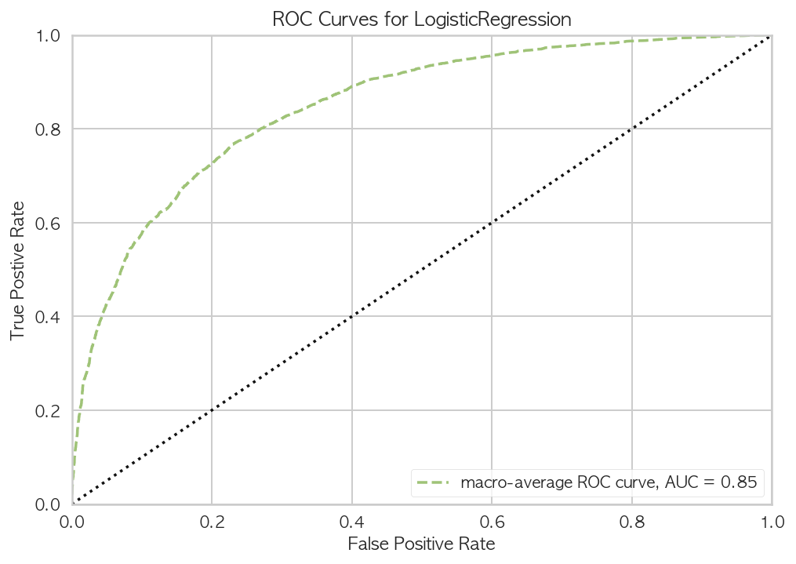

```python
from yellowbrick.classifier import ROCAUC

visualizer = ROCAUC(lr,
                    classes=[0, 1],
                    micro=False,
                    macro=True,
                    per_class=False)

visualizer.fit(df1, y)
visualizer.score(df1, y)
visualizer.show()

plt.show()
```

```python
from sklearn.metrics import roc_curve, auc

fpr, tpr, thresholds = roc_curve(y, preds)

auc(fpr, tpr)
```

```
0.8482074007474056
```

AUC(Area Under the Curve)는 ROC curve의 면적을 뜻한다. 위양성률값이 같을 때 재현률값이 크거나 재현률값이 같을 때 위양성률값이 작을수록 AUC가 1에 가까운 값이고 좋은 모형이다.

[AUC 기준]

- 0.9 ~ 1 : Excellent
- 0.8 ~ 0.9 : Good
- 0.7 ~ 0.8 : Normal
- 0.6 ~ 0.7 : Poor
- 0.5 ~ 0.6 : Fail

현재 로짓 모델의 AUC는 0.85수준으로 Good 수준으로 평가될 수 있습니다.